# Submission1

## Q.1.1

An Exchange-Traded Fund (ETF) is an investment fund that holds assets such as stocks, commodities, bonds, or foreign currency. An ETF is traded like a stock throughout the trading day at fluctuating prices. They often track indexes. There are many types of Exchange-Traded Funds. Some of the most common ETFs include Stocks, Index, Bonds, Currency, Invese ETF, Actively Managed, Leveraged and Real Estate ETF

```python
#Q 1.2 Calculate average of a specific fund using purely python and NOT pandas
# importing csv module
import csv
import random


# csv file name
file = open("/Users/monika/Documents/WQUMSC/ML in Finance/M3/MScFE 650 MLF GWP Data.csv", 'r')
# creating dictreader object
file = csv.DictReader(file)
# craeting empty lists
List1= []
# iterating over each row and append
# values to empty list
for col in file:
  List1.append(col['MSCI ARGENTINA'])
my_list = [float(i) for i in List1]
print(my_list)
rand = []
for i in range(len(my_list)):
  rand.append(random.uniform(0, 1))

print(*List1, sep='\n')
```

[output not shown]

[output not shown]

[output not shown]

[output cut: 198 more lines]

```
1500.9
1537.73
1558.95
1607.73
1543.66
1514.52
1536.23
1478.64
1491.53
1509.07
1450.64
1506.32
1617.45
1628.12
1618.83
```

```python
# Q2.1 Import the data from the csv file
import pandas as pd
data = pd.read_csv("/Users/monika/Documents/WQUMSC/ML in Finance/M3/MScFE 650 MLF GWP Data.csv")
print(data.head())
```

```
        Date     LUXXX  MSCI ARGENTINA  BLP ORIENTE MEDIO  MSCI AUSTRALIA  \
0   1-Jan-16  1390.716         2376.29          3525.9150         1068.79
1   8-Jan-16  1291.267         2260.85          3280.6683         1005.56
2  15-Jan-16  1257.086         2217.50          3118.2981          985.38
3  22-Jan-16  1254.167         2281.98          2935.0677          985.87
4  29-Jan-16  1298.240         2462.19          3134.0840         1005.56

   MSCI AUSTRIA  MSCI BELGIUM  MSCI BRAZIL  MSCI CANADA  MSCI CHINA  ...  \
0        106.70        105.38      1036.23      1663.27       59.47  ...
1         97.66         99.35       952.01      1586.18       54.63  ...
2         93.54         97.32       904.64      1541.08       51.54  ...
3         95.79        100.73       879.17      1582.10       51.15  ...
4         96.93        103.05       958.97      1638.84       52.13  ...

   MSCI NORWAY  MSCI PERU  MSCI RUSSIA  MSCI SINGAPORE  MSCI SOUTH AFRICA  \
0      2373.17     811.96       404.73       1507.8101            1255.75
1      2209.38     751.09       388.05       1437.6600            1177.76
2      2095.60     720.23       344.45       1372.9800            1133.72
3      2173.55     745.96       367.44       1350.0500            1160.48
4      2214.88     825.18       400.93       1375.1000            1239.58

   MSCI SPAIN  MSCI SWEDEN  MSCI SWITZERLAND  MSCI UK  MSCI USA
0      108.40     11136.65           1148.37  1818.40   1949.70
1      101.00     10389.93           1075.30  1722.00   1831.88
2       97.34     10042.32           1056.01  1692.43   1789.56
3       99.21     10469.07           1076.48  1719.61   1814.12
4      100.06     10432.42           1087.17  1774.40   1843.88

[5 rows x 36 columns]
```

```python
# Q2.2 Summarize the min, max, mean, median, and standard deviation of each column
data.describe()
```

|  | LUXXX | MSCI ARGENTINA | BLP ORIENTE MEDIO | MSCI AUSTRALIA | MSCI AUSTRIA | MSCI BELGIUM | MSCI BRAZIL | MSCI CANADA | MSCI CHINA | MSCI DENMARK | ... | MSCI NORWAY | MSCI PERU | MSCI RUSSIA | MSCI SINGAPORE | MSCI SOUTH AFRICA | MSCI SPAIN | MSCI SWEDEN | MSCI SWITZERLAND | MSCI UK | MSCI USA |
| --- | --- | --- | --- | --- | --- | --- | --- | --- | --- | --- | --- | --- | --- | --- | --- | --- | --- | --- | --- | --- | --- |
| count | 252.000000 | 252.000000 | 252.000000 | 252.000000 | 252.000000 | 252.000000 | 252.000000 | 252.000000 | 252.000000 | 252.000000 | ... | 252.000000 | 252.000000 | 252.000000 | 252.000000 | 252.000000 | 252.000000 | 252.000000 | 252.000000 | 252.000000 | 252.000000 |
| mean | 1457.231905 | 2526.652262 | 3029.482978 | 1183.940159 | 127.418889 | 91.290238 | 1813.989167 | 1970.821627 | 76.788214 | 8447.657738 | ... | 2720.597183 | 1460.507817 | 595.207738 | 1618.220755 | 1348.088135 | 106.673413 | 12385.389048 | 1208.081468 | 2013.187579 | 2526.448532 |
| std | 238.611226 | 899.378857 | 516.678825 | 101.261295 | 24.770889 | 12.106033 | 354.986912 | 143.502890 | 13.192648 | 978.216958 | ... | 292.192348 | 284.660584 | 92.229158 | 157.305041 | 93.417184 | 12.367770 | 1101.073211 | 113.761591 | 181.105639 | 382.318512 |
| min | 871.500000 | 844.090000 | 1722.870000 | 957.150000 | 78.290000 | 57.440000 | 879.170000 | 1503.010000 | 48.160000 | 6671.370000 | ... | 2049.320000 | 720.230000 | 344.450000 | 1263.900000 | 942.480000 | 76.340000 | 9901.400000 | 1001.930000 | 1484.410000 | 1768.520000 |
| 25% | 1320.741000 | 1773.735000 | 2730.897500 | 1125.265000 | 102.820000 | 86.830000 | 1589.772500 | 1901.960000 | 66.552500 | 7912.862500 | ... | 2509.495000 | 1224.482500 | 536.347500 | 1478.917525 | 1295.695000 | 99.715000 | 11769.345000 | 1131.110000 | 1937.375000 | 2242.712500 |
| 50% | 1491.081000 | 2541.975000 | 3113.414050 | 1177.375000 | 130.635000 | 95.015000 | 1860.960000 | 1990.630000 | 78.710000 | 8227.805000 | ... | 2795.265000 | 1555.135000 | 594.125000 | 1666.280000 | 1351.055000 | 109.280000 | 12526.645000 | 1194.815000 | 2081.695000 | 2559.080000 |
| 75% | 1656.015500 | 3138.222500 | 3460.390000 | 1241.797500 | 146.950000 | 100.512500 | 2116.162500 | 2076.865000 | 86.532500 | 8554.552500 | ... | 2985.502500 | 1692.932500 | 643.987500 | 1728.582500 | 1403.500000 | 114.397500 | 12975.560000 | 1299.405000 | 2146.630000 | 2777.425000 |
| max | 1812.010000 | 4467.410000 | 3750.865500 | 1431.460000 | 177.580000 | 107.340000 | 2404.740000 | 2261.280000 | 103.540000 | 11852.360000 | ... | 3217.240000 | 1892.670000 | 852.930000 | 1920.630000 | 1591.700000 | 128.220000 | 14989.150000 | 1484.520000 | 2255.520000 | 3386.440000 |

8 rows × 35 columns

```python
# minimum value of each column
data.min()
```

```
Date                      1-Apr-16
LUXXX                        871.5
MSCI ARGENTINA              844.09
BLP ORIENTE MEDIO          1722.87
MSCI AUSTRALIA              957.15
MSCI AUSTRIA                 78.29
MSCI BELGIUM                 57.44
MSCI BRAZIL                 879.17
MSCI CANADA                1503.01
MSCI CHINA                   48.16
MSCI DENMARK               6671.37
MSCI EM ASIA                357.16
MSCI EM EU-MIDE-AFRICA     166.652
MSCI EM EUROPE              216.88
MSCI EM LATIN AMERICA      1482.97
MSCI FINLAND                 93.87
MSCI FRANCE                 113.79
MSCI GERMANY                103.11
MSCI HONG KONG             10473.3
MSCI INDIA                  873.94
MSCI ITALY                    42.5
MSCI JAPAN                  723.88
MSCI KOREA                   491.8
MSCI MEXICO                2804.73
MSCI NETHERLANDS            104.95
MSCI NEW ZEALAND            110.15
MSCI NORWAY                2049.32
MSCI PERU                   720.23
MSCI RUSSIA                 344.45
MSCI SINGAPORE              1263.9
MSCI SOUTH AFRICA           942.48
MSCI SPAIN                   76.34
MSCI SWEDEN                 9901.4
MSCI SWITZERLAND           1001.93
MSCI UK                    1484.41
MSCI USA                   1768.52
dtype: object
```

```python
# maximum value of each column
data.max()
```

```
Date                      9-Sep-16
LUXXX                      1812.01
MSCI ARGENTINA             4467.41
BLP ORIENTE MEDIO          3750.87
MSCI AUSTRALIA             1431.46
MSCI AUSTRIA                177.58
MSCI BELGIUM                107.34
MSCI BRAZIL                2404.74
MSCI CANADA                2261.28
MSCI CHINA                  103.54
MSCI DENMARK               11852.4
MSCI EM ASIA                641.63
MSCI EM EU-MIDE-AFRICA     322.457
MSCI EM EUROPE              382.64
MSCI EM LATIN AMERICA      3241.47
MSCI FINLAND                136.78
MSCI FRANCE                 175.35
MSCI GERMANY                166.64
MSCI HONG KONG             16997.4
MSCI INDIA                 1403.52
MSCI ITALY                   67.18
MSCI JAPAN                 1123.82
MSCI KOREA                  781.63
MSCI MEXICO                6145.47
MSCI NETHERLANDS            178.57
MSCI NEW ZEALAND            205.44
MSCI NORWAY                3217.24
MSCI PERU                  1892.67
MSCI RUSSIA                 852.93
MSCI SINGAPORE             1920.63
MSCI SOUTH AFRICA           1591.7
MSCI SPAIN                  128.22
MSCI SWEDEN                14989.1
MSCI SWITZERLAND           1484.52
MSCI UK                    2255.52
MSCI USA                   3386.44
dtype: object
```

```python
# median of each column
data.median()
```

```
LUXXX                      1491.08100
MSCI ARGENTINA             2541.97500
BLP ORIENTE MEDIO          3113.41405
MSCI AUSTRALIA             1177.37500
MSCI AUSTRIA                130.63500
MSCI BELGIUM                 95.01500
MSCI BRAZIL                1860.96000
MSCI CANADA                1990.63000
MSCI CHINA                   78.71000
MSCI DENMARK               8227.80500
MSCI EM ASIA                517.31000
MSCI EM EU-MIDE-AFRICA      251.16550
MSCI EM EUROPE              306.43000
MSCI EM LATIN AMERICA      2598.95500
MSCI FINLAND                124.12000
MSCI FRANCE                 147.93000
MSCI GERMANY                144.64500
MSCI HONG KONG            14342.61000
MSCI INDIA                 1230.79000
MSCI ITALY                   55.96000
MSCI JAPAN                  953.66000
MSCI KOREA                  649.64000
MSCI MEXICO                4948.77000
MSCI NETHERLANDS            143.67500
MSCI NEW ZEALAND            135.85000
MSCI NORWAY                2795.26500
MSCI PERU                  1555.13500
MSCI RUSSIA                 594.12500
MSCI SINGAPORE             1666.28000
MSCI SOUTH AFRICA          1351.05500
MSCI SPAIN                  109.28000
MSCI SWEDEN               12526.64500
MSCI SWITZERLAND           1194.81500
MSCI UK                    2081.69500
MSCI USA                   2559.08000
dtype: float64
```

```python
# standard deviation of each column
data.std()
```

```
LUXXX                      238.611226
MSCI ARGENTINA             899.378857
BLP ORIENTE MEDIO          516.678825
MSCI AUSTRALIA             101.261295
MSCI AUSTRIA                24.770889
MSCI BELGIUM                12.106033
MSCI BRAZIL                354.986912
MSCI CANADA                143.502890
MSCI CHINA                  13.192648
MSCI DENMARK               978.216958
MSCI EM ASIA                66.154751
MSCI EM EU-MIDE-AFRICA      27.880897
MSCI EM EUROPE              35.676634
MSCI EM LATIN AMERICA      391.780333
MSCI FINLAND                 9.374700
MSCI FRANCE                 14.256886
MSCI GERMANY                11.913640
MSCI HONG KONG            1520.792385
MSCI INDIA                 136.821780
MSCI ITALY                   5.813782
MSCI JAPAN                  87.779355
MSCI KOREA                  72.874560
MSCI MEXICO                725.375215
MSCI NETHERLANDS            16.532705
MSCI NEW ZEALAND            23.014514
MSCI NORWAY                292.192348
MSCI PERU                  284.660584
MSCI RUSSIA                 92.229158
MSCI SINGAPORE             157.305041
MSCI SOUTH AFRICA           93.417184
MSCI SPAIN                  12.367770
MSCI SWEDEN               1101.073211
MSCI SWITZERLAND           113.761591
MSCI UK                    181.105639
MSCI USA                   382.318512
dtype: float64
```

```python
# Set Date column as an index
data.set_index('Date', inplace=True)
data.head()
```

| Date | LUXXX | MSCI ARGENTINA | BLP ORIENTE MEDIO | MSCI AUSTRALIA | MSCI AUSTRIA | MSCI BELGIUM | MSCI BRAZIL | MSCI CANADA | MSCI CHINA | MSCI DENMARK | ... | MSCI NORWAY | MSCI PERU | MSCI RUSSIA | MSCI SINGAPORE | MSCI SOUTH AFRICA | MSCI SPAIN | MSCI SWEDEN | MSCI SWITZERLAND | MSCI UK | MSCI USA |
| --- | --- | --- | --- | --- | --- | --- | --- | --- | --- | --- | --- | --- | --- | --- | --- | --- | --- | --- | --- | --- | --- |
| 1-Jan-16 | 1390.716 | 2376.29 | 3525.9150 | 1068.79 | 106.70 | 105.38 | 1036.23 | 1663.27 | 59.47 | 8566.71 | ... | 2373.17 | 811.96 | 404.73 | 1507.8101 | 1255.75 | 108.40 | 11136.65 | 1148.37 | 1818.40 | 1949.70 |
| 8-Jan-16 | 1291.267 | 2260.85 | 3280.6683 | 1005.56 | 97.66 | 99.35 | 952.01 | 1586.18 | 54.63 | 8183.00 | ... | 2209.38 | 751.09 | 388.05 | 1437.6600 | 1177.76 | 101.00 | 10389.93 | 1075.30 | 1722.00 | 1831.88 |
| 15-Jan-16 | 1257.086 | 2217.50 | 3118.2981 | 985.38 | 93.54 | 97.32 | 904.64 | 1541.08 | 51.54 | 7755.73 | ... | 2095.60 | 720.23 | 344.45 | 1372.9800 | 1133.72 | 97.34 | 10042.32 | 1056.01 | 1692.43 | 1789.56 |
| 22-Jan-16 | 1254.167 | 2281.98 | 2935.0677 | 985.87 | 95.79 | 100.73 | 879.17 | 1582.10 | 51.15 | 8035.69 | ... | 2173.55 | 745.96 | 367.44 | 1350.0500 | 1160.48 | 99.21 | 10469.07 | 1076.48 | 1719.61 | 1814.12 |
| 29-Jan-16 | 1298.240 | 2462.19 | 3134.0840 | 1005.56 | 96.93 | 103.05 | 958.97 | 1638.84 | 52.13 | 8211.17 | ... | 2214.88 | 825.18 | 400.93 | 1375.1000 | 1239.58 | 100.06 | 10432.42 | 1087.17 | 1774.40 | 1843.88 |

5 rows × 35 columns

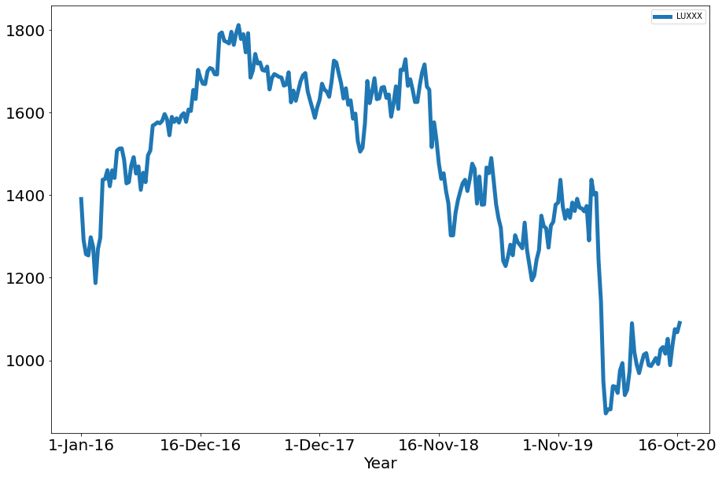

```python
# Q4.1 Write a Python function that graphs 1 time series with appropriate time labels
# Plot 1 time series
import matplotlib.pyplot as plt
def plot_series(series_data):
    series_data.plot(figsize=(15,10), linewidth=5, fontsize=20)
    plt.xlabel('Year', fontsize=20)

plot_series(data[['LUXXX']])
```

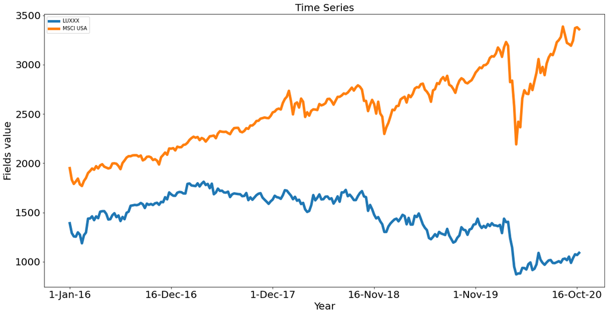

```python
# Q4.2 Write a Python function that graphs 2 time series on the same plot, with labels
#Concatenate together both series and plot them

def plot_two_series(X, Y):
    data_rm = pd.concat([X, Y], axis=1)
    data_rm.plot(figsize=(20,10), linewidth=5, fontsize=20)
    plt.xlabel('Year', fontsize=20)
    plt.ylabel('Fields value', fontsize=20)
    plt.title("Time Series", size=20)
plot_two_series(data[['LUXXX']], data[['MSCI USA']])
```

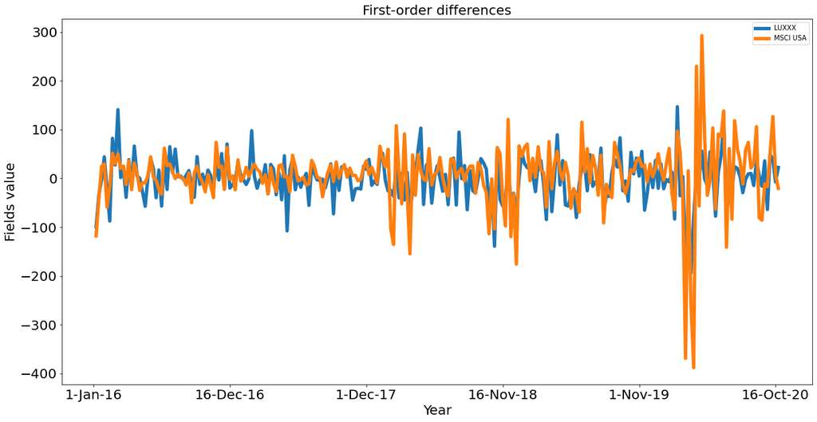

```python
#Q4.3 Write a Python function that compares the 2 return series
def plot_diff_series(data_rm):
    data_rm.diff().plot(figsize=(20,10), linewidth=5, fontsize=20)
    plt.xlabel('Year', fontsize=20);
    plt.ylabel('Fields value', fontsize=20);
    plt.title("First-order differences", size=20)

plot_diff_series(data_rm)
```

```python
# Q 5.1 Compute the correlation using Pearson correlation
#Importing  important libraries
import scipy
from scipy.stats.stats import pearsonr, spearmanr, kendalltau
# Using pandas function to compute our correlation
corr = data.corr(method='pearson')

## We have Created a correlation plot
corr.style.background_gradient(cmap='coolwarm')
```

|  | LUXXX | MSCI ARGENTINA | BLP ORIENTE MEDIO | MSCI AUSTRALIA | MSCI AUSTRIA | MSCI BELGIUM | MSCI BRAZIL | MSCI CANADA | MSCI CHINA | MSCI DENMARK | MSCI EM ASIA | MSCI EM EU-MIDE-AFRICA | MSCI EM EUROPE | MSCI EM LATIN AMERICA | MSCI FINLAND | MSCI FRANCE | MSCI GERMANY | MSCI HONG KONG | MSCI INDIA | MSCI ITALY | MSCI JAPAN | MSCI KOREA | MSCI MEXICO | MSCI NETHERLANDS | MSCI NEW ZEALAND | MSCI NORWAY | MSCI PERU | MSCI RUSSIA | MSCI SINGAPORE | … |
| --- | --- | --- | --- | --- | --- | --- | --- | --- | --- | --- | --- | --- | --- | --- | --- | --- | --- | --- | --- | --- | --- | --- | --- | --- | --- | --- | --- | --- | --- | --- |
| LUXXX | 1.000000 | 0.754584 | 0.823881 | 0.046895 | 0.674894 | 0.850111 | 0.337350 | 0.133539 | -0.192526 | -0.676507 | -0.045439 | 0.677351 | 0.380714 | 0.601071 | 0.119269 | 0.167161 | 0.557645 | 0.193620 | -0.152044 | 0.397034 | 0.224822 | 0.174025 | 0.859403 | -0.346658 | -0.734921 | 0.168444 | 0.349905 | -0.099556 | 0.556819 | … |
| MSCI ARGENTINA | 0.754584 | 1.000000 | 0.740835 | -0.160676 | 0.604493 | 0.747766 | 0.260126 | -0.047239 | -0.000917 | -0.474811 | 0.110893 | 0.678930 | 0.350046 | 0.510696 | 0.010117 | 0.015244 | 0.508243 | 0.218971 | -0.203116 | 0.371382 | 0.188907 | 0.310811 | 0.759354 | -0.336182 | -0.713526 | 0.026683 | 0.242801 | -0.225743 | 0.501144 | … |
| BLP ORIENTE MEDIO | 0.823881 | 0.740835 | 1.000000 | -0.124534 | 0.387526 | 0.925401 | 0.144240 | -0.114781 | -0.449813 | -0.616805 | -0.312487 | 0.492296 | 0.222905 | 0.396939 | -0.197143 | -0.069617 | 0.359587 | -0.111512 | -0.424088 | 0.261513 | -0.088410 | -0.094217 | 0.823201 | -0.485341 | -0.727424 | -0.184801 | 0.002905 | -0.265565 | 0.318689 | … |
| MSCI AUSTRALIA | 0.046895 | -0.160676 | -0.124534 | 1.000000 | 0.516601 | -0.027924 | 0.755042 | 0.916125 | 0.536852 | 0.284185 | 0.599384 | 0.508376 | 0.765606 | 0.624283 | 0.718873 | 0.921855 | 0.596349 | 0.735227 | 0.825480 | 0.703030 | 0.675393 | 0.540544 | 0.017388 | 0.771409 | 0.445050 | 0.810983 | 0.714497 | 0.894720 | 0.648469 | … |
| MSCI AUSTRIA | 0.674894 | 0.604493 | 0.387526 | 0.516601 | 1.000000 | 0.495019 | 0.731040 | 0.562506 | 0.438279 | -0.300536 | 0.550032 | 0.888062 | 0.813588 | 0.856685 | 0.591328 | 0.708573 | 0.801413 | 0.762312 | 0.454721 | 0.829645 | 0.764734 | 0.678859 | 0.605188 | 0.248228 | -0.359425 | 0.752971 | 0.825097 | 0.437568 | 0.934414 | … |
| MSCI BELGIUM | 0.850111 | 0.747766 | 0.925401 | -0.027924 | 0.495019 | 1.000000 | 0.209736 | -0.036849 | -0.369143 | -0.616392 | -0.230014 | 0.581903 | 0.304030 | 0.487311 | -0.067410 | 0.049484 | 0.416299 | 0.037509 | -0.304333 | 0.376750 | 0.000366 | -0.030710 | 0.899776 | -0.434554 | -0.744533 | -0.046238 | 0.139077 | -0.201364 | 0.444066 | … |
| MSCI BRAZIL | 0.337350 | 0.260126 | 0.144240 | 0.755042 | 0.731040 | 0.209736 | 1.000000 | 0.732142 | 0.465766 | -0.083163 | 0.562476 | 0.811979 | 0.910710 | 0.937938 | 0.556716 | 0.762449 | 0.609400 | 0.808712 | 0.654698 | 0.701297 | 0.606018 | 0.551653 | 0.294600 | 0.463748 | 0.043793 | 0.768825 | 0.865784 | 0.786482 | 0.810813 | … |
| MSCI CANADA | 0.133539 | -0.047239 | -0.114781 | 0.916125 | 0.562506 | -0.036849 | 0.732142 | 1.000000 | 0.676746 | 0.335889 | 0.741687 | 0.555424 | 0.744150 | 0.615089 | 0.783045 | 0.902872 | 0.731081 | 0.771960 | 0.845175 | 0.663895 | 0.770054 | 0.708383 | 0.008069 | 0.806199 | 0.453717 | 0.820085 | 0.729537 | 0.849771 | 0.624717 | … |
| MSCI CHINA | -0.192526 | -0.000917 | -0.449813 | 0.536852 | 0.438279 | -0.369143 | 0.465766 | 0.676746 | 1.000000 | 0.602393 | 0.980782 | 0.377255 | 0.518319 | 0.337513 | 0.731391 | 0.667324 | 0.561679 | 0.755195 | 0.810124 | 0.517451 | 0.786816 | 0.891796 | -0.217102 | 0.814460 | 0.518594 | 0.683251 | 0.578218 | 0.590822 | 0.440631 | … |
| MSCI DENMARK | -0.676507 | -0.474811 | -0.616805 | 0.284185 | -0.300536 | -0.616392 | -0.083163 | 0.335889 | 0.602393 | 1.000000 | 0.537414 | -0.275134 | -0.002492 | -0.292335 | 0.370449 | 0.272837 | 0.101663 | 0.111802 | 0.499613 | 0.060431 | 0.268285 | 0.400754 | -0.552746 | 0.750802 | 0.862406 | 0.116178 | -0.117812 | 0.328008 | -0.235455 | … |
| MSCI EM ASIA | -0.045439 | 0.110893 | -0.312487 | 0.599384 | 0.550032 | -0.230014 | 0.562476 | 0.741687 | 0.980782 | 0.537414 | 1.000000 | 0.508016 | 0.620950 | 0.467240 | 0.784398 | 0.738670 | 0.683208 | 0.806367 | 0.838369 | 0.611033 | 0.837984 | 0.948674 | -0.066669 | 0.807795 | 0.441927 | 0.730191 | 0.650415 | 0.620535 | 0.547277 | … |
| MSCI EM EU-MIDE-AFRICA | 0.677351 | 0.678930 | 0.492296 | 0.508376 | 0.888062 | 0.581903 | 0.811979 | 0.555424 | 0.377255 | -0.275134 | 0.508016 | 1.000000 | 0.881798 | 0.931378 | 0.480662 | 0.621200 | 0.762237 | 0.734016 | 0.410492 | 0.770851 | 0.602970 | 0.597350 | 0.667883 | 0.191670 | -0.336744 | 0.622900 | 0.787283 | 0.482181 | 0.905670 | … |
| MSCI EM EUROPE | 0.380714 | 0.350046 | 0.222905 | 0.765606 | 0.813588 | 0.304030 | 0.910710 | 0.744150 | 0.518319 | -0.002492 | 0.620950 | 0.881798 | 1.000000 | 0.897558 | 0.585310 | 0.834675 | 0.744637 | 0.803875 | 0.623068 | 0.858254 | 0.719759 | 0.649406 | 0.391699 | 0.510970 | 0.021077 | 0.773220 | 0.824290 | 0.802070 | 0.886820 | … |
| MSCI EM LATIN AMERICA | 0.601071 | 0.510696 | 0.396939 | 0.624283 | 0.856685 | 0.487311 | 0.937938 | 0.615089 | 0.337513 | -0.292335 | 0.467240 | 0.931378 | 0.897558 | 1.000000 | 0.512609 | 0.685381 | 0.678317 | 0.768037 | 0.504514 | 0.748893 | 0.573063 | 0.530360 | 0.594542 | 0.249800 | -0.248381 | 0.703998 | 0.860000 | 0.589807 | 0.894070 | … |
| MSCI FINLAND | 0.119269 | 0.010117 | -0.197143 | 0.718873 | 0.591328 | -0.067410 | 0.556716 | 0.783045 | 0.731391 | 0.370449 | 0.784398 | 0.480662 | 0.585310 | 0.512609 | 1.000000 | 0.829987 | 0.702688 | 0.754730 | 0.828073 | 0.682122 | 0.811264 | 0.788039 | 0.078394 | 0.744040 | 0.311045 | 0.805568 | 0.681521 | 0.592711 | 0.588817 | … |
| MSCI FRANCE | 0.167161 | 0.015244 | -0.069617 | 0.921855 | 0.708573 | 0.049484 | 0.762449 | 0.902872 | 0.667324 | 0.272837 | 0.738670 | 0.621200 | 0.834675 | 0.685381 | 0.829987 | 1.000000 | 0.770995 | 0.828817 | 0.836623 | 0.859708 | 0.850319 | 0.733682 | 0.136678 | 0.794073 | 0.320820 | 0.887446 | 0.783253 | 0.840328 | 0.774149 | … |
| MSCI GERMANY | 0.557645 | 0.508243 | 0.359587 | 0.596349 | 0.801413 | 0.416299 | 0.609400 | 0.731081 | 0.561679 | 0.101663 | 0.683208 | 0.762237 | 0.744637 | 0.678317 | 0.702688 | 0.770995 | 1.000000 | 0.650133 | 0.527630 | 0.827521 | 0.819520 | 0.815246 | 0.464404 | 0.518198 | -0.028734 | 0.626064 | 0.592658 | 0.481570 | 0.735126 | … |
| MSCI HONG KONG | 0.193620 | 0.218971 | -0.111512 | 0.735227 | 0.762312 | 0.037509 | 0.808712 | 0.771960 | 0.755195 | 0.111802 | 0.806367 | 0.734016 | 0.803875 | 0.768037 | 0.754730 | 0.828817 | 0.650133 | 1.000000 | 0.815165 | 0.734740 | 0.765841 | 0.764741 | 0.174508 | 0.615175 | 0.152724 | 0.871809 | 0.912244 | 0.703397 | 0.832000 | … |
| MSCI INDIA | -0.152044 | -0.203116 | -0.424088 | 0.825480 | 0.454721 | -0.304333 | 0.654698 | 0.845175 | 0.810124 | 0.499613 | 0.838369 | 0.410492 | 0.623068 | 0.504514 | 0.828073 | 0.836623 | 0.527630 | 0.815165 | 1.000000 | 0.572822 | 0.747881 | 0.728174 | -0.143959 | 0.848907 | 0.553366 | 0.847703 | 0.735808 | 0.777754 | 0.531416 | … |
| MSCI ITALY | 0.397034 | 0.371382 | 0.261513 | 0.703030 | 0.829645 | 0.376750 | 0.701297 | 0.663895 | 0.517451 | 0.060431 | 0.611033 | 0.770851 | 0.858254 | 0.748893 | 0.682122 | 0.859708 | 0.827521 | 0.734740 | 0.572822 | 1.000000 | 0.791706 | 0.687460 | 0.454741 | 0.517491 | -0.049240 | 0.731187 | 0.701279 | 0.610154 | 0.871461 | … |
| MSCI JAPAN | 0.224822 | 0.188907 | -0.088410 | 0.675393 | 0.764734 | 0.000366 | 0.606018 | 0.770054 | 0.786816 | 0.268285 | 0.837984 | 0.602970 | 0.719759 | 0.573063 | 0.811264 | 0.850319 | 0.819520 | 0.765841 | 0.747881 | 0.791706 | 1.000000 | 0.877640 | 0.116303 | 0.690502 | 0.189339 | 0.857096 | 0.722494 | 0.642880 | 0.716889 | … |
| MSCI KOREA | 0.174025 | 0.310811 | -0.094217 | 0.540544 | 0.678859 | -0.030710 | 0.551653 | 0.708383 | 0.891796 | 0.400754 | 0.948674 | 0.597350 | 0.649406 | 0.530360 | 0.788039 | 0.733682 | 0.815246 | 0.764741 | 0.728174 | 0.687460 | 0.877640 | 1.000000 | 0.135402 | 0.703445 | 0.247132 | 0.704305 | 0.641384 | 0.517339 | 0.618111 | … |
| MSCI MEXICO | 0.859403 | 0.759354 | 0.823201 | 0.017388 | 0.605188 | 0.899776 | 0.294600 | 0.008069 | -0.217102 | -0.552746 | -0.066669 | 0.667883 | 0.391699 | 0.594542 | 0.078394 | 0.136678 | 0.464404 | 0.174508 | -0.143959 | 0.454741 | 0.116303 | 0.135402 | 1.000000 | -0.352958 | -0.719310 | 0.085427 | 0.283869 | -0.156685 | 0.542155 | … |
| MSCI NETHERLANDS | -0.346658 | -0.336182 | -0.485341 | 0.771409 | 0.248228 | -0.434554 | 0.463748 | 0.806199 | 0.814460 | 0.750802 | 0.807795 | 0.191670 | 0.510970 | 0.249800 | 0.744040 | 0.794073 | 0.518198 | 0.615175 | 0.848907 | 0.517491 | 0.690502 | 0.703445 | -0.352958 | 1.000000 | 0.779703 | 0.647383 | 0.441340 | 0.769865 | 0.317571 | … |
| MSCI NEW ZEALAND | -0.734921 | -0.713526 | -0.727424 | 0.445050 | -0.359425 | -0.744533 | 0.043793 | 0.453717 | 0.518594 | 0.862406 | 0.441927 | -0.336744 | 0.021077 | -0.248381 | 0.311045 | 0.320820 | -0.028734 | 0.152724 | 0.553366 | -0.049240 | 0.189339 | 0.247132 | -0.719310 | 0.779703 | 1.000000 | 0.190491 | -0.027402 | 0.517976 | -0.251964 | … |
| MSCI NORWAY | 0.168444 | 0.026683 | -0.184801 | 0.810983 | 0.752971 | -0.046238 | 0.768825 | 0.820085 | 0.683251 | 0.116178 | 0.730191 | 0.622900 | 0.773220 | 0.703998 | 0.805568 | 0.887446 | 0.626064 | 0.871809 | 0.847703 | 0.731187 | 0.857096 | 0.704305 | 0.085427 | 0.647383 | 0.190491 | 1.000000 | 0.915892 | 0.778128 | 0.785991 | … |
| MSCI PERU | 0.349905 | 0.242801 | 0.002905 | 0.714497 | 0.825097 | 0.139077 | 0.865784 | 0.729537 | 0.578218 | -0.117812 | 0.650415 | 0.787283 | 0.824290 | 0.860000 | 0.681521 | 0.783253 | 0.592658 | 0.912244 | 0.735808 | 0.701279 | 0.722494 | 0.641384 | 0.283869 | 0.441340 | -0.027402 | 0.915892 | 1.000000 | 0.693583 | 0.875027 | … |
| MSCI RUSSIA | -0.099556 | -0.225743 | -0.265565 | 0.894720 | 0.437568 | -0.201364 | 0.786482 | 0.849771 | 0.590822 | 0.328008 | 0.620535 | 0.482181 | 0.802070 | 0.589807 | 0.592711 | 0.840328 | 0.481570 | 0.703397 | 0.777754 | 0.610154 | 0.642880 | 0.517339 | -0.156685 | 0.769865 | 0.517976 | 0.778128 | 0.693583 | 1.000000 | 0.576680 | … |
| MSCI SINGAPORE | 0.556819 | 0.501144 | 0.318689 | 0.648469 | 0.934414 | 0.444066 | 0.810813 | 0.624717 | 0.440631 | -0.235455 | 0.547277 | 0.905670 | 0.886820 | 0.894070 | 0.588817 | 0.774149 | 0.735126 | 0.832000 | 0.531416 | 0.871461 | 0.716889 | 0.618111 | 0.542155 | 0.317571 | -0.251964 | 0.785991 | 0.875027 | 0.576680 | 1.000000 | … |
| MSCI SOUTH AFRICA | 0.527276 | 0.607563 | 0.402231 | 0.458925 | 0.725589 | 0.547095 | 0.622795 | 0.541088 | 0.417123 | -0.063860 | 0.531768 | 0.865521 | 0.724090 | 0.754356 | 0.478915 | 0.550115 | 0.707273 | 0.673136 | 0.451201 | 0.672603 | 0.530532 | 0.595001 | 0.613496 | 0.233371 | -0.211221 | 0.550174 | 0.667274 | 0.365085 | 0.764887 | … |
| MSCI SPAIN | 0.797206 | 0.661643 | 0.646010 | 0.445205 | 0.876846 | 0.724709 | 0.631839 | 0.428865 | 0.114691 | -0.425734 | 0.260161 | 0.833450 | 0.726507 | 0.809039 | 0.431522 | 0.594502 | 0.761356 | 0.559649 | 0.223916 | 0.794406 | 0.519020 | 0.439903 | 0.776770 | 0.078329 | -0.484709 | 0.498164 | 0.607831 | 0.284769 | 0.839139 | … |
| MSCI SWEDEN | -0.147922 | -0.209572 | -0.340203 | 0.775572 | 0.355420 | -0.302931 | 0.511825 | 0.857026 | 0.785007 | 0.654080 | 0.814161 | 0.287345 | 0.551754 | 0.341109 | 0.811111 | 0.829406 | 0.657983 | 0.635041 | 0.839595 | 0.574776 | 0.757163 | 0.767834 | -0.206846 | 0.947734 | 0.665081 | 0.673945 | 0.477045 | 0.742430 | 0.384128 | … |
| MSCI SWITZERLAND | -0.483619 | -0.459191 | -0.549976 | 0.755159 | 0.122654 | -0.500430 | 0.426602 | 0.724269 | 0.705410 | 0.766011 | 0.682794 | 0.077751 | 0.454385 | 0.175978 | 0.625120 | 0.729001 | 0.358818 | 0.538170 | 0.806178 | 0.435771 | 0.577852 | 0.549508 | -0.444455 | 0.953445 | 0.831110 | 0.584813 | 0.362580 | 0.775365 | 0.229751 | … |
| MSCI UK | 0.754859 | 0.517648 | 0.516283 | 0.607045 | 0.876490 | 0.627655 | 0.749572 | 0.623534 | 0.202909 | -0.401304 | 0.342088 | 0.857948 | 0.776731 | 0.871113 | 0.521132 | 0.686753 | 0.757130 | 0.677213 | 0.387794 | 0.737576 | 0.577869 | 0.466801 | 0.649240 | 0.184163 | -0.336463 | 0.655832 | 0.766019 | 0.463717 | 0.870869 | … |
| MSCI USA | -0.462818 | -0.461817 | -0.652986 | 0.715744 | 0.141123 | -0.602246 | 0.408112 | 0.759718 | 0.822201 | 0.763004 | 0.789612 | 0.086913 | 0.405691 | 0.165067 | 0.704050 | 0.696137 | 0.352547 | 0.580201 | 0.876559 | 0.356063 | 0.640564 | 0.637996 | -0.489888 | 0.947389 | 0.834796 | 0.654284 | 0.444981 | 0.752478 | 0.219050 | … |

```python
# Q 5.2 Recompute the calculation, instead of using Spearman correlation
corr = data.corr(method='spearman')

corr.style.background_gradient(cmap='coolwarm')
```

|  | LUXXX | MSCI ARGENTINA | BLP ORIENTE MEDIO | MSCI AUSTRALIA | MSCI AUSTRIA | MSCI BELGIUM | MSCI BRAZIL | MSCI CANADA | MSCI CHINA | MSCI DENMARK | MSCI EM ASIA | MSCI EM EU-MIDE-AFRICA | MSCI EM EUROPE | MSCI EM LATIN AMERICA | MSCI FINLAND | MSCI FRANCE | MSCI GERMANY | MSCI HONG KONG | MSCI INDIA | MSCI ITALY | MSCI JAPAN | MSCI KOREA | MSCI MEXICO | MSCI NETHERLANDS | MSCI NEW ZEALAND | MSCI NORWAY | MSCI PERU | MSCI RUSSIA | MSCI SINGAPORE | … |
| --- | --- | --- | --- | --- | --- | --- | --- | --- | --- | --- | --- | --- | --- | --- | --- | --- | --- | --- | --- | --- | --- | --- | --- | --- | --- | --- | --- | --- | --- | --- |
| LUXXX | 1.000000 | 0.760165 | 0.763908 | 0.008914 | 0.630077 | 0.728380 | 0.171258 | 0.014335 | -0.116688 | -0.538869 | 0.005798 | 0.554788 | 0.264879 | 0.364556 | 0.090323 | 0.124665 | 0.573083 | 0.139133 | -0.235222 | 0.321589 | 0.243513 | 0.233873 | 0.752881 | -0.341706 | -0.565547 | 0.135903 | 0.284113 | -0.189760 | 0.421563 | … |
| MSCI ARGENTINA | 0.760165 | 1.000000 | 0.762681 | -0.170967 | 0.543215 | 0.815686 | 0.189584 | -0.174087 | -0.049772 | -0.421900 | 0.060285 | 0.605042 | 0.275518 | 0.412710 | -0.093829 | -0.036529 | 0.458203 | 0.175782 | -0.343454 | 0.305101 | 0.113044 | 0.254280 | 0.776578 | -0.411066 | -0.719957 | -0.085017 | 0.211169 | -0.274679 | 0.416496 | … |
| BLP ORIENTE MEDIO | 0.763908 | 0.762681 | 1.000000 | -0.225116 | 0.305152 | 0.881598 | 0.022868 | -0.222396 | -0.415513 | -0.453115 | -0.295090 | 0.359850 | 0.124695 | 0.192335 | -0.296949 | -0.127153 | 0.328552 | -0.178697 | -0.520241 | 0.188173 | -0.118720 | -0.080790 | 0.712599 | -0.491070 | -0.661538 | -0.270019 | -0.103185 | -0.373495 | 0.187038 | … |
| MSCI AUSTRALIA | 0.008914 | -0.170967 | -0.225116 | 1.000000 | 0.522231 | -0.222302 | 0.702757 | 0.936633 | 0.545906 | 0.408691 | 0.595389 | 0.543726 | 0.751379 | 0.606095 | 0.703204 | 0.918585 | 0.579334 | 0.764185 | 0.831537 | 0.703167 | 0.672674 | 0.540290 | -0.085123 | 0.759239 | 0.486747 | 0.830269 | 0.706822 | 0.838601 | 0.689851 | … |
| MSCI AUSTRIA | 0.630077 | 0.543215 | 0.305152 | 0.522231 | 1.000000 | 0.368606 | 0.674107 | 0.472486 | 0.446277 | -0.078353 | 0.554642 | 0.882219 | 0.790899 | 0.810203 | 0.526612 | 0.695327 | 0.797265 | 0.757600 | 0.351085 | 0.823141 | 0.760857 | 0.683685 | 0.570112 | 0.208147 | -0.265385 | 0.712182 | 0.797891 | 0.403134 | 0.902973 | … |
| MSCI BELGIUM | 0.728380 | 0.815686 | 0.881598 | -0.222302 | 0.368606 | 1.000000 | 0.014034 | -0.221215 | -0.307498 | -0.368589 | -0.190399 | 0.406781 | 0.124331 | 0.219109 | -0.222442 | -0.090045 | 0.351937 | -0.077921 | -0.461633 | 0.227466 | -0.062708 | 0.001082 | 0.825553 | -0.463197 | -0.666000 | -0.235713 | -0.050673 | -0.410777 | 0.238371 | … |
| MSCI BRAZIL | 0.171258 | 0.189584 | 0.022868 | 0.702757 | 0.674107 | 0.014034 | 1.000000 | 0.615794 | 0.413264 | 0.104694 | 0.484752 | 0.780311 | 0.912577 | 0.946705 | 0.452480 | 0.724075 | 0.528819 | 0.784765 | 0.574307 | 0.729318 | 0.551163 | 0.473854 | 0.143528 | 0.416505 | 0.102561 | 0.689064 | 0.809696 | 0.769487 | 0.792500 | … |
| MSCI CANADA | 0.014335 | -0.174087 | -0.222396 | 0.936633 | 0.472486 | -0.221215 | 0.615794 | 1.000000 | 0.635031 | 0.471316 | 0.675563 | 0.506866 | 0.691672 | 0.524926 | 0.718225 | 0.898737 | 0.633048 | 0.728359 | 0.850564 | 0.669726 | 0.723428 | 0.604681 | -0.122878 | 0.816690 | 0.519158 | 0.813339 | 0.649712 | 0.809950 | 0.625193 | … |
| MSCI CHINA | -0.116688 | -0.049772 | -0.415513 | 0.545906 | 0.446277 | -0.307498 | 0.413264 | 0.635031 | 1.000000 | 0.608738 | 0.976460 | 0.444056 | 0.518441 | 0.412224 | 0.686739 | 0.618130 | 0.579344 | 0.720008 | 0.723093 | 0.539614 | 0.782682 | 0.882349 | -0.106270 | 0.778314 | 0.436034 | 0.629511 | 0.535999 | 0.589147 | 0.485453 | … |
| MSCI DENMARK | -0.538869 | -0.421900 | -0.453115 | 0.408691 | -0.078353 | -0.368589 | 0.104694 | 0.471316 | 0.608738 | 1.000000 | 0.564055 | -0.017833 | 0.220099 | 0.028048 | 0.380487 | 0.428612 | 0.195366 | 0.286369 | 0.564102 | 0.281249 | 0.358074 | 0.428970 | -0.309892 | 0.793448 | 0.660324 | 0.259644 | 0.009157 | 0.416429 | 0.080001 | … |
| MSCI EM ASIA | 0.005798 | 0.060285 | -0.295090 | 0.595389 | 0.554642 | -0.190399 | 0.484752 | 0.675563 | 0.976460 | 0.564055 | 1.000000 | 0.550016 | 0.603762 | 0.505052 | 0.745814 | 0.683264 | 0.692340 | 0.760859 | 0.751925 | 0.634538 | 0.845821 | 0.946446 | 0.030473 | 0.760187 | 0.364832 | 0.675426 | 0.593295 | 0.585406 | 0.577162 | … |
| MSCI EM EU-MIDE-AFRICA | 0.554788 | 0.605042 | 0.359850 | 0.543726 | 0.882219 | 0.406781 | 0.780311 | 0.506866 | 0.444056 | -0.017833 | 0.550016 | 1.000000 | 0.883425 | 0.895182 | 0.444207 | 0.667622 | 0.776824 | 0.790636 | 0.360034 | 0.821472 | 0.627359 | 0.637712 | 0.552953 | 0.241798 | -0.203210 | 0.598706 | 0.782790 | 0.479146 | 0.912567 | … |
| MSCI EM EUROPE | 0.264879 | 0.275518 | 0.124695 | 0.751379 | 0.790899 | 0.124331 | 0.912577 | 0.691672 | 0.518441 | 0.220099 | 0.603762 | 0.883425 | 1.000000 | 0.916331 | 0.510146 | 0.829968 | 0.718118 | 0.825808 | 0.570596 | 0.891228 | 0.694143 | 0.628414 | 0.274203 | 0.498219 | 0.067409 | 0.728157 | 0.789132 | 0.774898 | 0.897248 | … |
| MSCI EM LATIN AMERICA | 0.364556 | 0.412710 | 0.192335 | 0.606095 | 0.810203 | 0.219109 | 0.946705 | 0.524926 | 0.412224 | 0.028048 | 0.505052 | 0.895182 | 0.916331 | 1.000000 | 0.446577 | 0.687142 | 0.620776 | 0.804109 | 0.465722 | 0.784867 | 0.589196 | 0.548896 | 0.399969 | 0.293822 | -0.093770 | 0.665523 | 0.827683 | 0.612284 | 0.869062 | … |
| MSCI FINLAND | 0.090323 | -0.093829 | -0.296949 | 0.703204 | 0.526612 | -0.222442 | 0.452480 | 0.718225 | 0.686739 | 0.380487 | 0.745814 | 0.444207 | 0.510146 | 0.446577 | 1.000000 | 0.753292 | 0.604203 | 0.696228 | 0.774696 | 0.588370 | 0.754927 | 0.740698 | 0.035607 | 0.681887 | 0.384850 | 0.775794 | 0.642412 | 0.551806 | 0.531659 | … |
| MSCI FRANCE | 0.124665 | -0.036529 | -0.127153 | 0.918585 | 0.695327 | -0.090045 | 0.724075 | 0.898737 | 0.618130 | 0.428612 | 0.683264 | 0.667622 | 0.829968 | 0.687142 | 0.753292 | 1.000000 | 0.729765 | 0.828424 | 0.786725 | 0.851862 | 0.803878 | 0.669709 | 0.078714 | 0.753841 | 0.344384 | 0.879872 | 0.757896 | 0.787641 | 0.809771 | … |
| MSCI GERMANY | 0.573083 | 0.458203 | 0.328552 | 0.579334 | 0.797265 | 0.351937 | 0.528819 | 0.633048 | 0.579344 | 0.195366 | 0.692340 | 0.776824 | 0.718118 | 0.620776 | 0.604203 | 0.729765 | 1.000000 | 0.625576 | 0.440242 | 0.826214 | 0.806180 | 0.818664 | 0.456905 | 0.469343 | -0.034919 | 0.592025 | 0.549425 | 0.411513 | 0.731907 | … |
| MSCI HONG KONG | 0.139133 | 0.175782 | -0.178697 | 0.764185 | 0.757600 | -0.077921 | 0.784765 | 0.728359 | 0.720008 | 0.286369 | 0.760859 | 0.790636 | 0.825808 | 0.804109 | 0.696228 | 0.828424 | 0.625576 | 1.000000 | 0.732414 | 0.759122 | 0.737920 | 0.725266 | 0.137992 | 0.588606 | 0.202927 | 0.823495 | 0.907675 | 0.710589 | 0.862625 | … |
| MSCI INDIA | -0.235222 | -0.343454 | -0.520241 | 0.831537 | 0.351085 | -0.461633 | 0.574307 | 0.850564 | 0.723093 | 0.564102 | 0.751925 | 0.360034 | 0.570596 | 0.465722 | 0.774696 | 0.786725 | 0.440242 | 0.732414 | 1.000000 | 0.520993 | 0.683833 | 0.629575 | -0.237456 | 0.838880 | 0.638929 | 0.796775 | 0.635146 | 0.753177 | 0.486570 | … |
| MSCI ITALY | 0.321589 | 0.305101 | 0.188173 | 0.703167 | 0.823141 | 0.227466 | 0.729318 | 0.669726 | 0.539614 | 0.281249 | 0.634538 | 0.821472 | 0.891228 | 0.784867 | 0.588370 | 0.851862 | 0.826214 | 0.759122 | 0.520993 | 1.000000 | 0.777435 | 0.690169 | 0.375362 | 0.500246 | -0.038022 | 0.706904 | 0.690203 | 0.612768 | 0.883761 | … |
| MSCI JAPAN | 0.243513 | 0.113044 | -0.118720 | 0.672674 | 0.760857 | -0.062708 | 0.551163 | 0.723428 | 0.782682 | 0.358074 | 0.845821 | 0.627359 | 0.694143 | 0.589196 | 0.754927 | 0.803878 | 0.806180 | 0.737920 | 0.683833 | 0.777435 | 1.000000 | 0.875573 | 0.154186 | 0.627689 | 0.178806 | 0.838214 | 0.692618 | 0.599476 | 0.727990 | … |
| MSCI KOREA | 0.233873 | 0.254280 | -0.080790 | 0.540290 | 0.683685 | 0.001082 | 0.473854 | 0.604681 | 0.882349 | 0.428970 | 0.946446 | 0.637712 | 0.628414 | 0.548896 | 0.740698 | 0.669709 | 0.818664 | 0.725266 | 0.629575 | 0.690169 | 0.875573 | 1.000000 | 0.224723 | 0.639937 | 0.188537 | 0.647441 | 0.586183 | 0.472399 | 0.629640 | … |
| MSCI MEXICO | 0.752881 | 0.776578 | 0.712599 | -0.085123 | 0.570112 | 0.825553 | 0.143528 | -0.122878 | -0.106270 | -0.309892 | 0.030473 | 0.552953 | 0.274203 | 0.399969 | 0.035607 | 0.078714 | 0.456905 | 0.137992 | -0.237456 | 0.375362 | 0.154186 | 0.224723 | 1.000000 | -0.351708 | -0.614661 | 0.014419 | 0.178495 | -0.297960 | 0.419028 | … |
| MSCI NETHERLANDS | -0.341706 | -0.411066 | -0.491070 | 0.759239 | 0.208147 | -0.463197 | 0.416505 | 0.816690 | 0.778314 | 0.793448 | 0.760187 | 0.241798 | 0.498219 | 0.293822 | 0.681887 | 0.753841 | 0.469343 | 0.588606 | 0.838880 | 0.500246 | 0.627689 | 0.639937 | -0.351708 | 1.000000 | 0.740662 | 0.620127 | 0.382055 | 0.739077 | 0.356815 | … |
| MSCI NEW ZEALAND | -0.565547 | -0.719957 | -0.661538 | 0.486747 | -0.265385 | -0.666000 | 0.102561 | 0.519158 | 0.436034 | 0.660324 | 0.364832 | -0.203210 | 0.067409 | -0.093770 | 0.384850 | 0.344384 | -0.034919 | 0.202927 | 0.638929 | -0.038022 | 0.178806 | 0.188537 | -0.614661 | 0.740662 | 1.000000 | 0.306813 | 0.057448 | 0.502064 | -0.111920 | … |
| MSCI NORWAY | 0.135903 | -0.085017 | -0.270019 | 0.830269 | 0.712182 | -0.235713 | 0.689064 | 0.813339 | 0.629511 | 0.259644 | 0.675426 | 0.598706 | 0.728157 | 0.665523 | 0.775794 | 0.879872 | 0.592025 | 0.823495 | 0.796775 | 0.706904 | 0.838214 | 0.647441 | 0.014419 | 0.620127 | 0.306813 | 1.000000 | 0.861984 | 0.753355 | 0.758055 | … |
| MSCI PERU | 0.284113 | 0.211169 | -0.103185 | 0.706822 | 0.797891 | -0.050673 | 0.809696 | 0.649712 | 0.535999 | 0.009157 | 0.593295 | 0.782790 | 0.789132 | 0.827683 | 0.642412 | 0.757896 | 0.549425 | 0.907675 | 0.635146 | 0.690203 | 0.692618 | 0.586183 | 0.178495 | 0.382055 | 0.057448 | 0.861984 | 1.000000 | 0.679512 | 0.858325 | … |
| MSCI RUSSIA | -0.189760 | -0.274679 | -0.373495 | 0.838601 | 0.403134 | -0.410777 | 0.769487 | 0.809950 | 0.589147 | 0.416429 | 0.585406 | 0.479146 | 0.774898 | 0.612284 | 0.551806 | 0.787641 | 0.411513 | 0.710589 | 0.753177 | 0.612768 | 0.599476 | 0.472399 | -0.297960 | 0.739077 | 0.502064 | 0.753355 | 0.679512 | 1.000000 | 0.594943 | … |
| MSCI SINGAPORE | 0.421563 | 0.416496 | 0.187038 | 0.689851 | 0.902973 | 0.238371 | 0.792500 | 0.625193 | 0.485453 | 0.080001 | 0.577162 | 0.912567 | 0.897248 | 0.869062 | 0.531659 | 0.809771 | 0.731907 | 0.862625 | 0.486570 | 0.883761 | 0.727990 | 0.629640 | 0.419028 | 0.356815 | -0.111920 | 0.758055 | 0.858325 | 0.594943 | 1.000000 | … |
| MSCI SOUTH AFRICA | 0.386641 | 0.515793 | 0.241724 | 0.494837 | 0.726394 | 0.415367 | 0.567375 | 0.486469 | 0.469770 | 0.151474 | 0.557440 | 0.831082 | 0.697118 | 0.706004 | 0.422578 | 0.597809 | 0.617991 | 0.729144 | 0.401593 | 0.677185 | 0.541215 | 0.580346 | 0.552596 | 0.262712 | -0.102399 | 0.546659 | 0.670459 | 0.347782 | 0.798022 | … |
| MSCI SPAIN | 0.696801 | 0.611122 | 0.503483 | 0.493137 | 0.878057 | 0.527247 | 0.602130 | 0.444318 | 0.282470 | -0.061556 | 0.411059 | 0.870351 | 0.756895 | 0.742838 | 0.443075 | 0.652110 | 0.851786 | 0.631991 | 0.246133 | 0.830552 | 0.591287 | 0.581179 | 0.647633 | 0.189496 | -0.283941 | 0.515598 | 0.611159 | 0.299059 | 0.813230 | … |
| MSCI SWEDEN | -0.108966 | -0.263058 | -0.316342 | 0.749297 | 0.324909 | -0.300457 | 0.425370 | 0.817390 | 0.723844 | 0.676213 | 0.759750 | 0.316965 | 0.518085 | 0.344853 | 0.764766 | 0.777277 | 0.628847 | 0.576584 | 0.812089 | 0.561024 | 0.698279 | 0.718811 | -0.153888 | 0.903727 | 0.607039 | 0.635008 | 0.397677 | 0.651809 | 0.404788 | … |
| MSCI SWITZERLAND | -0.443921 | -0.502658 | -0.548127 | 0.714589 | 0.128467 | -0.530308 | 0.425297 | 0.739852 | 0.689994 | 0.826300 | 0.663824 | 0.160211 | 0.463796 | 0.278910 | 0.594973 | 0.688419 | 0.357876 | 0.529511 | 0.812789 | 0.431478 | 0.556233 | 0.544759 | -0.426858 | 0.944624 | 0.789875 | 0.570966 | 0.318203 | 0.727862 | 0.279391 | … |
| MSCI UK | 0.646838 | 0.486479 | 0.382994 | 0.621821 | 0.846133 | 0.417859 | 0.595758 | 0.604094 | 0.323534 | -0.029171 | 0.435467 | 0.843056 | 0.734335 | 0.704862 | 0.522153 | 0.742505 | 0.807998 | 0.694960 | 0.369231 | 0.770979 | 0.638628 | 0.556779 | 0.519315 | 0.285671 | -0.108874 | 0.660142 | 0.707536 | 0.390594 | 0.841259 | … |
| MSCI USA | -0.445698 | -0.564665 | -0.668146 | 0.727221 | 0.121610 | -0.660276 | 0.389331 | 0.766393 | 0.751277 | 0.733555 | 0.712667 | 0.113260 | 0.407159 | 0.230499 | 0.671729 | 0.673231 | 0.299403 | 0.544782 | 0.872379 | 0.353462 | 0.593711 | 0.559387 | -0.486971 | 0.938132 | 0.817515 | 0.652479 | 0.400580 | 0.764934 | 0.266993 | … |

```python
# Q 5.3 Recompute the calculation, instead of using Kendall correlation
corr = data.corr(method='kendall')

corr.style.background_gradient(cmap='coolwarm')
```

|  | LUXXX | MSCI ARGENTINA | BLP ORIENTE MEDIO | MSCI AUSTRALIA | MSCI AUSTRIA | MSCI BELGIUM | MSCI BRAZIL | MSCI CANADA | MSCI CHINA | MSCI DENMARK | MSCI EM ASIA | MSCI EM EU-MIDE-AFRICA | MSCI EM EUROPE | MSCI EM LATIN AMERICA | MSCI FINLAND | MSCI FRANCE | MSCI GERMANY | MSCI HONG KONG | MSCI INDIA | MSCI ITALY | MSCI JAPAN | MSCI KOREA | MSCI MEXICO | MSCI NETHERLANDS | MSCI NEW ZEALAND | MSCI NORWAY | MSCI PERU | MSCI RUSSIA | MSCI SINGAPORE | … |
| --- | --- | --- | --- | --- | --- | --- | --- | --- | --- | --- | --- | --- | --- | --- | --- | --- | --- | --- | --- | --- | --- | --- | --- | --- | --- | --- | --- | --- | --- | --- |
| LUXXX | 1.000000 | 0.558401 | 0.580861 | 0.026877 | 0.457578 | 0.533989 | 0.110099 | 0.052488 | -0.058753 | -0.365459 | 0.018689 | 0.385037 | 0.176063 | 0.264023 | 0.071664 | 0.099271 | 0.382076 | 0.103522 | -0.149560 | 0.205503 | 0.162914 | 0.161897 | 0.576741 | -0.194346 | -0.385226 | 0.116739 | 0.192977 | -0.093657 | 0.283916 | … |
| MSCI ARGENTINA | 0.558401 | 1.000000 | 0.547910 | -0.091383 | 0.382000 | 0.601097 | 0.158351 | -0.084424 | -0.022009 | -0.242965 | 0.054548 | 0.442649 | 0.208696 | 0.305571 | -0.040354 | -0.003510 | 0.304788 | 0.145450 | -0.163663 | 0.218027 | 0.072856 | 0.169170 | 0.568456 | -0.221414 | -0.506657 | -0.013849 | 0.188740 | -0.153292 | 0.289924 | … |
| BLP ORIENTE MEDIO | 0.580861 | 0.547910 | 1.000000 | -0.117454 | 0.234036 | 0.704980 | 0.030232 | -0.115679 | -0.250095 | -0.306242 | -0.165373 | 0.257325 | 0.108251 | 0.134969 | -0.184527 | -0.054750 | 0.217598 | -0.076276 | -0.331794 | 0.140562 | -0.044213 | -0.031688 | 0.549807 | -0.314548 | -0.436446 | -0.116817 | -0.046962 | -0.190564 | 0.158721 | … |
| MSCI AUSTRALIA | 0.026877 | -0.091383 | -0.117454 | 1.000000 | 0.340839 | -0.131216 | 0.522182 | 0.785012 | 0.369162 | 0.297233 | 0.408538 | 0.366456 | 0.568113 | 0.424917 | 0.515197 | 0.750897 | 0.416622 | 0.557217 | 0.648032 | 0.506151 | 0.481422 | 0.378194 | -0.055526 | 0.612213 | 0.381760 | 0.625075 | 0.497304 | 0.665802 | 0.483075 | … |
| MSCI AUSTRIA | 0.457578 | 0.382000 | 0.234036 | 0.340839 | 1.000000 | 0.273741 | 0.485153 | 0.324764 | 0.400430 | -0.047307 | 0.476937 | 0.713321 | 0.603883 | 0.624039 | 0.389854 | 0.486281 | 0.608685 | 0.544793 | 0.247415 | 0.629914 | 0.586635 | 0.590032 | 0.408816 | 0.186838 | -0.192600 | 0.516966 | 0.592205 | 0.284160 | 0.744375 | … |
| MSCI BELGIUM | 0.533989 | 0.601097 | 0.704980 | -0.131216 | 0.273741 | 1.000000 | 0.022485 | -0.126279 | -0.180685 | -0.238232 | -0.098045 | 0.295130 | 0.100666 | 0.151199 | -0.117383 | -0.031694 | 0.270840 | -0.011353 | -0.278965 | 0.180898 | -0.019261 | 0.015718 | 0.629750 | -0.293025 | -0.443330 | -0.104837 | -0.023403 | -0.244746 | 0.178684 | … |
| MSCI BRAZIL | 0.110099 | 0.158351 | 0.030232 | 0.522182 | 0.485153 | 0.022485 | 1.000000 | 0.452413 | 0.319757 | 0.097704 | 0.361661 | 0.592149 | 0.741059 | 0.801429 | 0.326376 | 0.527601 | 0.376384 | 0.585910 | 0.430722 | 0.528843 | 0.379775 | 0.340617 | 0.103586 | 0.313243 | 0.088733 | 0.503889 | 0.641286 | 0.581737 | 0.588354 | … |
| MSCI CANADA | 0.052488 | -0.084424 | -0.115679 | 0.785012 | 0.324764 | -0.126279 | 0.452413 | 1.000000 | 0.446180 | 0.324670 | 0.484608 | 0.352153 | 0.519589 | 0.372984 | 0.527324 | 0.733227 | 0.463601 | 0.530703 | 0.662746 | 0.482922 | 0.520554 | 0.442245 | -0.067097 | 0.639514 | 0.370363 | 0.621451 | 0.466997 | 0.638462 | 0.440625 | … |
| MSCI CHINA | -0.058753 | -0.022009 | -0.250095 | 0.369162 | 0.400430 | -0.180685 | 0.319757 | 0.446180 | 1.000000 | 0.430686 | 0.883671 | 0.387781 | 0.409322 | 0.365292 | 0.499020 | 0.441229 | 0.422011 | 0.592967 | 0.557804 | 0.399772 | 0.580482 | 0.711381 | -0.062105 | 0.595408 | 0.339015 | 0.452568 | 0.430534 | 0.424741 | 0.451658 | … |
| MSCI DENMARK | -0.365459 | -0.242965 | -0.306242 | 0.297233 | -0.047307 | -0.238232 | 0.097704 | 0.324670 | 0.430686 | 1.000000 | 0.389046 | 0.009075 | 0.190103 | 0.038260 | 0.250727 | 0.318875 | 0.132186 | 0.175741 | 0.401252 | 0.222201 | 0.230458 | 0.283383 | -0.187694 | 0.608652 | 0.503494 | 0.164675 | 0.009075 | 0.282869 | 0.075414 | … |
| MSCI EM ASIA | 0.018689 | 0.054548 | -0.165373 | 0.408538 | 0.476937 | -0.098045 | 0.361661 | 0.484608 | 0.883671 | 0.389046 | 1.000000 | 0.464788 | 0.471531 | 0.418075 | 0.548842 | 0.491049 | 0.510792 | 0.622543 | 0.591048 | 0.474516 | 0.649084 | 0.803131 | 0.028175 | 0.580586 | 0.273841 | 0.487138 | 0.458148 | 0.430092 | 0.515195 | … |
| MSCI EM EU-MIDE-AFRICA | 0.385037 | 0.442649 | 0.257325 | 0.366456 | 0.713321 | 0.295130 | 0.592149 | 0.352153 | 0.387781 | 0.009075 | 0.464788 | 1.000000 | 0.708470 | 0.742660 | 0.308765 | 0.453384 | 0.578562 | 0.584433 | 0.255711 | 0.621673 | 0.445650 | 0.508372 | 0.405717 | 0.188499 | -0.128548 | 0.402618 | 0.585866 | 0.336659 | 0.745486 | … |
| MSCI EM EUROPE | 0.176063 | 0.208696 | 0.108251 | 0.568113 | 0.603883 | 0.100666 | 0.741059 | 0.519589 | 0.409322 | 0.190103 | 0.471531 | 0.708470 | 1.000000 | 0.737012 | 0.356748 | 0.634767 | 0.532684 | 0.614071 | 0.421945 | 0.717100 | 0.503684 | 0.471983 | 0.201992 | 0.393132 | 0.074252 | 0.529644 | 0.594318 | 0.590482 | 0.711695 | … |
| MSCI EM LATIN AMERICA | 0.264023 | 0.305571 | 0.134969 | 0.424917 | 0.624039 | 0.151199 | 0.801429 | 0.372984 | 0.365292 | 0.038260 | 0.418075 | 0.742660 | 0.737012 | 1.000000 | 0.316635 | 0.474534 | 0.445449 | 0.600455 | 0.339151 | 0.578305 | 0.405452 | 0.423336 | 0.282805 | 0.231786 | -0.034279 | 0.449377 | 0.636733 | 0.441978 | 0.687515 | … |
| MSCI FINLAND | 0.071664 | -0.040354 | -0.184527 | 0.515197 | 0.389854 | -0.117383 | 0.326376 | 0.527324 | 0.499020 | 0.250727 | 0.548842 | 0.308765 | 0.356748 | 0.316635 | 1.000000 | 0.568505 | 0.432566 | 0.495003 | 0.572423 | 0.409312 | 0.571700 | 0.555299 | 0.029032 | 0.502941 | 0.258089 | 0.585263 | 0.464745 | 0.382859 | 0.397065 | … |
| MSCI FRANCE | 0.099271 | -0.003510 | -0.054750 | 0.750897 | 0.486281 | -0.031694 | 0.527601 | 0.733227 | 0.441229 | 0.318875 | 0.491049 | 0.453384 | 0.634767 | 0.474534 | 0.568505 | 1.000000 | 0.548479 | 0.633545 | 0.606410 | 0.655807 | 0.624223 | 0.494853 | 0.052972 | 0.639025 | 0.257611 | 0.697238 | 0.547375 | 0.610142 | 0.592094 | … |
| MSCI GERMANY | 0.382076 | 0.304788 | 0.217598 | 0.416622 | 0.608685 | 0.270840 | 0.376384 | 0.463601 | 0.422011 | 0.132186 | 0.510792 | 0.578562 | 0.532684 | 0.445449 | 0.432566 | 0.548479 | 1.000000 | 0.450889 | 0.308836 | 0.624684 | 0.624605 | 0.629139 | 0.313516 | 0.350158 | -0.022455 | 0.414522 | 0.387806 | 0.281260 | 0.533846 | … |
| MSCI HONG KONG | 0.103522 | 0.145450 | -0.076276 | 0.557217 | 0.544793 | -0.011353 | 0.585910 | 0.530703 | 0.592967 | 0.175741 | 0.622543 | 0.584433 | 0.614071 | 0.600455 | 0.495003 | 0.633545 | 0.450889 | 1.000000 | 0.565421 | 0.535231 | 0.543701 | 0.554751 | 0.101562 | 0.431634 | 0.138254 | 0.631759 | 0.726724 | 0.525454 | 0.659246 | … |
| MSCI INDIA | -0.149560 | -0.163663 | -0.331794 | 0.648032 | 0.247415 | -0.278965 | 0.430722 | 0.662746 | 0.557804 | 0.401252 | 0.591048 | 0.255711 | 0.421945 | 0.339151 | 0.572423 | 0.606410 | 0.308836 | 0.565421 | 1.000000 | 0.349273 | 0.493296 | 0.471146 | -0.133055 | 0.657539 | 0.465105 | 0.609878 | 0.476483 | 0.588566 | 0.354429 | … |
| MSCI ITALY | 0.205503 | 0.218027 | 0.140562 | 0.506151 | 0.629914 | 0.180898 | 0.528843 | 0.482922 | 0.399772 | 0.222201 | 0.474516 | 0.621673 | 0.717100 | 0.578305 | 0.409312 | 0.655807 | 0.624684 | 0.535231 | 0.349273 | 1.000000 | 0.581694 | 0.508175 | 0.264769 | 0.373142 | -0.014739 | 0.501328 | 0.488907 | 0.431436 | 0.688278 | … |
| MSCI JAPAN | 0.162914 | 0.072856 | -0.044213 | 0.481422 | 0.586635 | -0.019261 | 0.379775 | 0.520554 | 0.580482 | 0.230458 | 0.649084 | 0.445650 | 0.503684 | 0.405452 | 0.571700 | 0.624223 | 0.624605 | 0.543701 | 0.493296 | 0.581694 | 1.000000 | 0.689245 | 0.106059 | 0.457403 | 0.118402 | 0.643941 | 0.493968 | 0.427081 | 0.547030 | … |
| MSCI KOREA | 0.161897 | 0.169170 | -0.031688 | 0.378194 | 0.590032 | 0.015718 | 0.340617 | 0.442245 | 0.711381 | 0.283383 | 0.803131 | 0.508372 | 0.471983 | 0.423336 | 0.555299 | 0.494853 | 0.629139 | 0.554751 | 0.471146 | 0.508175 | 0.689245 | 1.000000 | 0.153929 | 0.483129 | 0.137373 | 0.482593 | 0.433620 | 0.345549 | 0.507423 | … |
| MSCI MEXICO | 0.576741 | 0.568456 | 0.549807 | -0.055526 | 0.408816 | 0.629750 | 0.103586 | -0.067097 | -0.062105 | -0.187694 | 0.028175 | 0.405717 | 0.201992 | 0.282805 | 0.029032 | 0.052972 | 0.313516 | 0.101562 | -0.133055 | 0.264769 | 0.106059 | 0.153929 | 1.000000 | -0.219707 | -0.423299 | 0.049010 | 0.138022 | -0.167457 | 0.297513 | … |
| MSCI NETHERLANDS | -0.194346 | -0.221414 | -0.314548 | 0.612213 | 0.186838 | -0.293025 | 0.313243 | 0.639514 | 0.595408 | 0.608652 | 0.580586 | 0.188499 | 0.393132 | 0.231786 | 0.502941 | 0.639025 | 0.350158 | 0.431634 | 0.657539 | 0.373142 | 0.457403 | 0.483129 | -0.219707 | 1.000000 | 0.554631 | 0.448963 | 0.279634 | 0.566152 | 0.310307 | … |
| MSCI NEW ZEALAND | -0.385226 | -0.506657 | -0.436446 | 0.381760 | -0.192600 | -0.443330 | 0.088733 | 0.370363 | 0.339015 | 0.503494 | 0.273841 | -0.128548 | 0.074252 | -0.034279 | 0.258089 | 0.257611 | -0.022455 | 0.138254 | 0.465105 | -0.014739 | 0.118402 | 0.137373 | -0.423299 | 0.554631 | 1.000000 | 0.203080 | 0.046012 | 0.367328 | -0.047719 | … |
| MSCI NORWAY | 0.116739 | -0.013849 | -0.116817 | 0.625075 | 0.516966 | -0.104837 | 0.503889 | 0.621451 | 0.452568 | 0.164675 | 0.487138 | 0.402618 | 0.529644 | 0.449377 | 0.585263 | 0.697238 | 0.414522 | 0.631759 | 0.609878 | 0.501328 | 0.643941 | 0.482593 | 0.049010 | 0.448963 | 0.203080 | 1.000000 | 0.658867 | 0.569152 | 0.535233 | … |
| MSCI PERU | 0.192977 | 0.188740 | -0.046962 | 0.497304 | 0.592205 | -0.023403 | 0.641286 | 0.466997 | 0.430534 | 0.009075 | 0.458148 | 0.585866 | 0.594318 | 0.636733 | 0.464745 | 0.547375 | 0.387806 | 0.726724 | 0.476483 | 0.488907 | 0.493968 | 0.433620 | 0.138022 | 0.279634 | 0.046012 | 0.658867 | 1.000000 | 0.484451 | 0.662893 | … |
| MSCI RUSSIA | -0.093657 | -0.153292 | -0.190564 | 0.665802 | 0.284160 | -0.244746 | 0.581737 | 0.638462 | 0.424741 | 0.282869 | 0.430092 | 0.336659 | 0.590482 | 0.441978 | 0.382859 | 0.610142 | 0.281260 | 0.525454 | 0.588566 | 0.431436 | 0.427081 | 0.345549 | -0.167457 | 0.566152 | 0.367328 | 0.569152 | 0.484451 | 1.000000 | 0.408689 | … |
| MSCI SINGAPORE | 0.283916 | 0.289924 | 0.158721 | 0.483075 | 0.744375 | 0.178684 | 0.588354 | 0.440625 | 0.451658 | 0.075414 | 0.515195 | 0.745486 | 0.711695 | 0.687515 | 0.397065 | 0.592094 | 0.533846 | 0.659246 | 0.354429 | 0.688278 | 0.547030 | 0.507423 | 0.297513 | 0.310307 | -0.047719 | 0.535233 | 0.662893 | 0.408689 | 1.000000 | … |
| MSCI SOUTH AFRICA | 0.277719 | 0.368595 | 0.173331 | 0.331800 | 0.547996 | 0.303163 | 0.390666 | 0.331916 | 0.351479 | 0.124045 | 0.410777 | 0.646640 | 0.507802 | 0.521699 | 0.279669 | 0.402593 | 0.443591 | 0.529288 | 0.268359 | 0.490741 | 0.379812 | 0.424892 | 0.386429 | 0.175408 | -0.066693 | 0.372136 | 0.474561 | 0.233577 | 0.606609 | … |
| MSCI SPAIN | 0.513574 | 0.408525 | 0.354054 | 0.303170 | 0.704005 | 0.415143 | 0.405806 | 0.295318 | 0.249545 | -0.035765 | 0.329971 | 0.678873 | 0.544707 | 0.553291 | 0.318400 | 0.436840 | 0.672275 | 0.405932 | 0.144165 | 0.625128 | 0.442136 | 0.451482 | 0.485430 | 0.153472 | -0.172957 | 0.329154 | 0.402302 | 0.184388 | 0.629732 | … |
| MSCI SWEDEN | -0.039841 | -0.144628 | -0.205743 | 0.575557 | 0.250830 | -0.189592 | 0.298236 | 0.636375 | 0.540665 | 0.492127 | 0.577830 | 0.227822 | 0.384759 | 0.252451 | 0.572106 | 0.624184 | 0.460312 | 0.407892 | 0.626194 | 0.401645 | 0.516064 | 0.545518 | -0.094416 | 0.753478 | 0.436834 | 0.469171 | 0.272849 | 0.492380 | 0.320722 | … |
| MSCI SWITZERLAND | -0.256976 | -0.281830 | -0.350679 | 0.566744 | 0.113558 | -0.321505 | 0.326667 | 0.559896 | 0.510854 | 0.632686 | 0.485975 | 0.136601 | 0.357097 | 0.225103 | 0.445453 | 0.535357 | 0.277817 | 0.382698 | 0.631990 | 0.308955 | 0.405679 | 0.385366 | -0.257356 | 0.806647 | 0.592268 | 0.400721 | 0.235573 | 0.550663 | 0.238798 | … |
| MSCI UK | 0.461898 | 0.335863 | 0.263804 | 0.433455 | 0.677165 | 0.321089 | 0.410042 | 0.443875 | 0.281495 | -0.011257 | 0.354958 | 0.668733 | 0.530466 | 0.532473 | 0.391271 | 0.531206 | 0.622035 | 0.492886 | 0.269399 | 0.557242 | 0.457943 | 0.434783 | 0.366597 | 0.250063 | -0.053569 | 0.467021 | 0.505573 | 0.275723 | 0.657855 | … |
| MSCI USA | -0.277493 | -0.313350 | -0.425590 | 0.599336 | 0.117130 | -0.430069 | 0.321634 | 0.594890 | 0.587971 | 0.554733 | 0.557528 | 0.116393 | 0.322403 | 0.205780 | 0.496648 | 0.538733 | 0.218456 | 0.406122 | 0.719282 | 0.254333 | 0.420946 | 0.426498 | -0.313223 | 0.805338 | 0.641369 | 0.503699 | 0.330271 | 0.605072 | 0.244455 | … |

```python
# Q 6.1  Choose one of the 35 variables to serve as your response variable (e.g. LUXXX)
# import relevant libraries
import numpy as np
from matplotlib import pyplot as plt
from sklearn.decomposition import PCA
from sklearn.preprocessing import StandardScaler
from sklearn.model_selection import train_test_split, cross_val_score
from sklearn.linear_model import Lasso
from sklearn.metrics import mean_squared_error,r2_score
from sklearn import model_selection
from sklearn import linear_model
data = pd.read_csv("/Users/monika/Documents/WQUMSC/ML in Finance/M3/MScFE 650 MLF GWP Data.csv")

# set Date column as index
df1 = data.set_index('Date')

df_MSCI_JPN = df1['MSCI JAPAN']

df2 = df1.drop(['MSCI JAPAN'],axis=1)
df2
```

| Date | LUXXX | MSCI ARGENTINA | BLP ORIENTE MEDIO | MSCI AUSTRALIA | MSCI AUSTRIA | MSCI BELGIUM | MSCI BRAZIL | MSCI CANADA | MSCI CHINA | MSCI DENMARK | ... | MSCI NORWAY | MSCI PERU | MSCI RUSSIA | MSCI SINGAPORE | MSCI SOUTH AFRICA | MSCI SPAIN | MSCI SWEDEN | MSCI SWITZERLAND | MSCI UK | MSCI USA |
| --- | --- | --- | --- | --- | --- | --- | --- | --- | --- | --- | --- | --- | --- | --- | --- | --- | --- | --- | --- | --- | --- |
| 1-Jan-16 | 1390.716 | 2376.29 | 3525.9150 | 1068.79 | 106.70 | 105.38 | 1036.23 | 1663.27 | 59.47 | 8566.71 | ... | 2373.17 | 811.96 | 404.73 | 1507.8101 | 1255.75 | 108.40 | 11136.65 | 1148.37 | 1818.40 | 1949.70 |
| 8-Jan-16 | 1291.267 | 2260.85 | 3280.6683 | 1005.56 | 97.66 | 99.35 | 952.01 | 1586.18 | 54.63 | 8183.00 | ... | 2209.38 | 751.09 | 388.05 | 1437.6600 | 1177.76 | 101.00 | 10389.93 | 1075.30 | 1722.00 | 1831.88 |
| 15-Jan-16 | 1257.086 | 2217.50 | 3118.2981 | 985.38 | 93.54 | 97.32 | 904.64 | 1541.08 | 51.54 | 7755.73 | ... | 2095.60 | 720.23 | 344.45 | 1372.9800 | 1133.72 | 97.34 | 10042.32 | 1056.01 | 1692.43 | 1789.56 |
| 22-Jan-16 | 1254.167 | 2281.98 | 2935.0677 | 985.87 | 95.79 | 100.73 | 879.17 | 1582.10 | 51.15 | 8035.69 | ... | 2173.55 | 745.96 | 367.44 | 1350.0500 | 1160.48 | 99.21 | 10469.07 | 1076.48 | 1719.61 | 1814.12 |
| 29-Jan-16 | 1298.240 | 2462.19 | 3134.0840 | 1005.56 | 96.93 | 103.05 | 958.97 | 1638.84 | 52.13 | 8211.17 | ... | 2214.88 | 825.18 | 400.93 | 1375.1000 | 1239.58 | 100.06 | 10432.42 | 1087.17 | 1774.40 | 1843.88 |
| ... | ... | ... | ... | ... | ... | ... | ... | ... | ... | ... | ... | ... | ... | ... | ... | ... | ... | ... | ... | ... | ... |
| 25-Sep-20 | 988.345 | 1450.64 | 2252.2500 | 1166.97 | 84.95 | 64.63 | 1424.53 | 2018.62 | 94.77 | 11122.05 | ... | 2570.43 | 1162.66 | 554.53 | 1328.1400 | 1238.65 | 78.45 | 14099.14 | 1362.07 | 1641.51 | 3191.72 |
| 2-Oct-20 | 1037.211 | 1506.32 | 2265.7000 | 1128.45 | 84.89 | 66.00 | 1365.07 | 2031.76 | 97.19 | 11389.27 | ... | 2587.30 | 1172.45 | 543.08 | 1344.0300 | 1276.25 | 79.97 | 14355.01 | 1368.78 | 1658.14 | 3243.91 |
| 9-Oct-20 | 1075.670 | 1617.45 | 2214.3200 | 1187.29 | 90.01 | 69.35 | 1447.85 | 2076.53 | 101.03 | 11779.71 | ... | 2635.08 | 1212.32 | 553.32 | 1358.9700 | 1291.47 | 82.44 | 14602.91 | 1375.90 | 1687.56 | 3370.62 |
| 16-Oct-20 | 1068.089 | 1628.12 | 2194.6300 | 1200.97 | 88.66 | 66.90 | 1430.12 | 2058.60 | 103.13 | 11852.36 | ... | 2622.38 | 1172.05 | 537.28 | 1366.6100 | 1290.69 | 81.31 | 14558.72 | 1360.43 | 1655.95 | 3379.31 |
| 23-Oct-20 | 1090.573 | 1618.83 | 2185.5500 | 1201.19 | 89.74 | 66.46 | 1478.56 | 2038.44 | 103.54 | 11508.96 | ... | 2618.11 | 1217.40 | 553.13 | 1360.9100 | 1306.22 | 81.81 | 14472.01 | 1337.48 | 1642.18 | 3358.93 |

252 rows × 34 columns

```python
# Q 7.1 Use the Pearson correlation matrix
df2.corr(method='pearson')
```

|  | LUXXX | MSCI ARGENTINA | BLP ORIENTE MEDIO | MSCI AUSTRALIA | MSCI AUSTRIA | MSCI BELGIUM | MSCI BRAZIL | MSCI CANADA | MSCI CHINA | MSCI DENMARK | ... | MSCI NORWAY | MSCI PERU | MSCI RUSSIA | MSCI SINGAPORE | MSCI SOUTH AFRICA | MSCI SPAIN | MSCI SWEDEN | MSCI SWITZERLAND | MSCI UK | MSCI USA |
| --- | --- | --- | --- | --- | --- | --- | --- | --- | --- | --- | --- | --- | --- | --- | --- | --- | --- | --- | --- | --- | --- |
| LUXXX | 1.000000 | 0.754584 | 0.823881 | 0.046895 | 0.674894 | 0.850111 | 0.337350 | 0.133539 | -0.192526 | -0.676507 | ... | 0.168444 | 0.349905 | -0.099556 | 0.556819 | 0.527276 | 0.797206 | -0.147922 | -0.483619 | 0.754859 | -0.462818 |
| MSCI ARGENTINA | 0.754584 | 1.000000 | 0.740835 | -0.160676 | 0.604493 | 0.747766 | 0.260126 | -0.047239 | -0.000917 | -0.474811 | ... | 0.026683 | 0.242801 | -0.225743 | 0.501144 | 0.607563 | 0.661643 | -0.209572 | -0.459191 | 0.517648 | -0.461817 |
| BLP ORIENTE MEDIO | 0.823881 | 0.740835 | 1.000000 | -0.124534 | 0.387526 | 0.925401 | 0.144240 | -0.114781 | -0.449813 | -0.616805 | ... | -0.184801 | 0.002905 | -0.265565 | 0.318689 | 0.402231 | 0.646010 | -0.340203 | -0.549976 | 0.516283 | -0.652986 |
| MSCI AUSTRALIA | 0.046895 | -0.160676 | -0.124534 | 1.000000 | 0.516601 | -0.027924 | 0.755042 | 0.916125 | 0.536852 | 0.284185 | ... | 0.810983 | 0.714497 | 0.894720 | 0.648469 | 0.458925 | 0.445205 | 0.775572 | 0.755159 | 0.607045 | 0.715744 |
| MSCI AUSTRIA | 0.674894 | 0.604493 | 0.387526 | 0.516601 | 1.000000 | 0.495019 | 0.731040 | 0.562506 | 0.438279 | -0.300536 | ... | 0.752971 | 0.825097 | 0.437568 | 0.934414 | 0.725589 | 0.876846 | 0.355420 | 0.122654 | 0.876490 | 0.141123 |
| MSCI BELGIUM | 0.850111 | 0.747766 | 0.925401 | -0.027924 | 0.495019 | 1.000000 | 0.209736 | -0.036849 | -0.369143 | -0.616392 | ... | -0.046238 | 0.139077 | -0.201364 | 0.444066 | 0.547095 | 0.724709 | -0.302931 | -0.500430 | 0.627655 | -0.602246 |
| MSCI BRAZIL | 0.337350 | 0.260126 | 0.144240 | 0.755042 | 0.731040 | 0.209736 | 1.000000 | 0.732142 | 0.465766 | -0.083163 | ... | 0.768825 | 0.865784 | 0.786482 | 0.810813 | 0.622795 | 0.631839 | 0.511825 | 0.426602 | 0.749572 | 0.408112 |
| MSCI CANADA | 0.133539 | -0.047239 | -0.114781 | 0.916125 | 0.562506 | -0.036849 | 0.732142 | 1.000000 | 0.676746 | 0.335889 | ... | 0.820085 | 0.729537 | 0.849771 | 0.624717 | 0.541088 | 0.428865 | 0.857026 | 0.724269 | 0.623534 | 0.759718 |
| MSCI CHINA | -0.192526 | -0.000917 | -0.449813 | 0.536852 | 0.438279 | -0.369143 | 0.465766 | 0.676746 | 1.000000 | 0.602393 | ... | 0.683251 | 0.578218 | 0.590822 | 0.440631 | 0.417123 | 0.114691 | 0.785007 | 0.705410 | 0.202909 | 0.822201 |
| MSCI DENMARK | -0.676507 | -0.474811 | -0.616805 | 0.284185 | -0.300536 | -0.616392 | -0.083163 | 0.335889 | 0.602393 | 1.000000 | ... | 0.116178 | -0.117812 | 0.328008 | -0.235455 | -0.063860 | -0.425734 | 0.654080 | 0.766011 | -0.401304 | 0.763004 |
| MSCI EM ASIA | -0.045439 | 0.110893 | -0.312487 | 0.599384 | 0.550032 | -0.230014 | 0.562476 | 0.741687 | 0.980782 | 0.537414 | ... | 0.730191 | 0.650415 | 0.620535 | 0.547277 | 0.531768 | 0.260161 | 0.814161 | 0.682794 | 0.342088 | 0.789612 |
| MSCI EM EU-MIDE-AFRICA | 0.677351 | 0.678930 | 0.492296 | 0.508376 | 0.888062 | 0.581903 | 0.811979 | 0.555424 | 0.377255 | -0.275134 | ... | 0.622900 | 0.787283 | 0.482181 | 0.905670 | 0.865521 | 0.833450 | 0.287345 | 0.077751 | 0.857948 | 0.086913 |
| MSCI EM EUROPE | 0.380714 | 0.350046 | 0.222905 | 0.765606 | 0.813588 | 0.304030 | 0.910710 | 0.744150 | 0.518319 | -0.002492 | ... | 0.773220 | 0.824290 | 0.802070 | 0.886820 | 0.724090 | 0.726507 | 0.551754 | 0.454385 | 0.776731 | 0.405691 |
| MSCI EM LATIN AMERICA | 0.601071 | 0.510696 | 0.396939 | 0.624283 | 0.856685 | 0.487311 | 0.937938 | 0.615089 | 0.337513 | -0.292335 | ... | 0.703998 | 0.860000 | 0.589807 | 0.894070 | 0.754356 | 0.809039 | 0.341109 | 0.175978 | 0.871113 | 0.165067 |
| MSCI FINLAND | 0.119269 | 0.010117 | -0.197143 | 0.718873 | 0.591328 | -0.067410 | 0.556716 | 0.783045 | 0.731391 | 0.370449 | ... | 0.805568 | 0.681521 | 0.592711 | 0.588817 | 0.478915 | 0.431522 | 0.811111 | 0.625120 | 0.521132 | 0.704050 |
| MSCI FRANCE | 0.167161 | 0.015244 | -0.069617 | 0.921855 | 0.708573 | 0.049484 | 0.762449 | 0.902872 | 0.667324 | 0.272837 | ... | 0.887446 | 0.783253 | 0.840328 | 0.774149 | 0.550115 | 0.594502 | 0.829406 | 0.729001 | 0.686753 | 0.696137 |
| MSCI GERMANY | 0.557645 | 0.508243 | 0.359587 | 0.596349 | 0.801413 | 0.416299 | 0.609400 | 0.731081 | 0.561679 | 0.101663 | ... | 0.626064 | 0.592658 | 0.481570 | 0.735126 | 0.707273 | 0.761356 | 0.657983 | 0.358818 | 0.757130 | 0.352547 |
| MSCI HONG KONG | 0.193620 | 0.218971 | -0.111512 | 0.735227 | 0.762312 | 0.037509 | 0.808712 | 0.771960 | 0.755195 | 0.111802 | ... | 0.871809 | 0.912244 | 0.703397 | 0.832000 | 0.673136 | 0.559649 | 0.635041 | 0.538170 | 0.677213 | 0.580201 |
| MSCI INDIA | -0.152044 | -0.203116 | -0.424088 | 0.825480 | 0.454721 | -0.304333 | 0.654698 | 0.845175 | 0.810124 | 0.499613 | ... | 0.847703 | 0.735808 | 0.777754 | 0.531416 | 0.451201 | 0.223916 | 0.839595 | 0.806178 | 0.387794 | 0.876559 |
| MSCI ITALY | 0.397034 | 0.371382 | 0.261513 | 0.703030 | 0.829645 | 0.376750 | 0.701297 | 0.663895 | 0.517451 | 0.060431 | ... | 0.731187 | 0.701279 | 0.610154 | 0.871461 | 0.672603 | 0.794406 | 0.574776 | 0.435771 | 0.737576 | 0.356063 |
| MSCI KOREA | 0.174025 | 0.310811 | -0.094217 | 0.540544 | 0.678859 | -0.030710 | 0.551653 | 0.708383 | 0.891796 | 0.400754 | ... | 0.704305 | 0.641384 | 0.517339 | 0.618111 | 0.595001 | 0.439903 | 0.767834 | 0.549508 | 0.466801 | 0.637996 |
| MSCI MEXICO | 0.859403 | 0.759354 | 0.823201 | 0.017388 | 0.605188 | 0.899776 | 0.294600 | 0.008069 | -0.217102 | -0.552746 | ... | 0.085427 | 0.283869 | -0.156685 | 0.542155 | 0.613496 | 0.776770 | -0.206846 | -0.444455 | 0.649240 | -0.489888 |
| MSCI NETHERLANDS | -0.346658 | -0.336182 | -0.485341 | 0.771409 | 0.248228 | -0.434554 | 0.463748 | 0.806199 | 0.814460 | 0.750802 | ... | 0.647383 | 0.441340 | 0.769865 | 0.317571 | 0.233371 | 0.078329 | 0.947734 | 0.953445 | 0.184163 | 0.947389 |
| MSCI NEW ZEALAND | -0.734921 | -0.713526 | -0.727424 | 0.445050 | -0.359425 | -0.744533 | 0.043793 | 0.453717 | 0.518594 | 0.862406 | ... | 0.190491 | -0.027402 | 0.517976 | -0.251964 | -0.211221 | -0.484709 | 0.665081 | 0.831110 | -0.336463 | 0.834796 |
| MSCI NORWAY | 0.168444 | 0.026683 | -0.184801 | 0.810983 | 0.752971 | -0.046238 | 0.768825 | 0.820085 | 0.683251 | 0.116178 | ... | 1.000000 | 0.915892 | 0.778128 | 0.785991 | 0.550174 | 0.498164 | 0.673945 | 0.584813 | 0.655832 | 0.654284 |
| MSCI PERU | 0.349905 | 0.242801 | 0.002905 | 0.714497 | 0.825097 | 0.139077 | 0.865784 | 0.729537 | 0.578218 | -0.117812 | ... | 0.915892 | 1.000000 | 0.693583 | 0.875027 | 0.667274 | 0.607831 | 0.477045 | 0.362580 | 0.766019 | 0.444981 |
| MSCI RUSSIA | -0.099556 | -0.225743 | -0.265565 | 0.894720 | 0.437568 | -0.201364 | 0.786482 | 0.849771 | 0.590822 | 0.328008 | ... | 0.778128 | 0.693583 | 1.000000 | 0.576680 | 0.365085 | 0.284769 | 0.742430 | 0.775365 | 0.463717 | 0.752478 |
| MSCI SINGAPORE | 0.556819 | 0.501144 | 0.318689 | 0.648469 | 0.934414 | 0.444066 | 0.810813 | 0.624717 | 0.440631 | -0.235455 | ... | 0.785991 | 0.875027 | 0.576680 | 1.000000 | 0.764887 | 0.839139 | 0.384128 | 0.229751 | 0.870869 | 0.219050 |
| MSCI SOUTH AFRICA | 0.527276 | 0.607563 | 0.402231 | 0.458925 | 0.725589 | 0.547095 | 0.622795 | 0.541088 | 0.417123 | -0.063860 | ... | 0.550174 | 0.667274 | 0.365085 | 0.764887 | 1.000000 | 0.660849 | 0.296408 | 0.127684 | 0.707134 | 0.146178 |
| MSCI SPAIN | 0.797206 | 0.661643 | 0.646010 | 0.445205 | 0.876846 | 0.724709 | 0.631839 | 0.428865 | 0.114691 | -0.425734 | ... | 0.498164 | 0.607831 | 0.284769 | 0.839139 | 0.660849 | 1.000000 | 0.215460 | -0.019807 | 0.903011 | -0.114703 |
| MSCI SWEDEN | -0.147922 | -0.209572 | -0.340203 | 0.775572 | 0.355420 | -0.302931 | 0.511825 | 0.857026 | 0.785007 | 0.654080 | ... | 0.673945 | 0.477045 | 0.742430 | 0.384128 | 0.296408 | 0.215460 | 1.000000 | 0.879340 | 0.307172 | 0.887809 |
| MSCI SWITZERLAND | -0.483619 | -0.459191 | -0.549976 | 0.755159 | 0.122654 | -0.500430 | 0.426602 | 0.724269 | 0.705410 | 0.766011 | ... | 0.584813 | 0.362580 | 0.775365 | 0.229751 | 0.127684 | -0.019807 | 0.879340 | 1.000000 | 0.085415 | 0.925526 |
| MSCI UK | 0.754859 | 0.517648 | 0.516283 | 0.607045 | 0.876490 | 0.627655 | 0.749572 | 0.623534 | 0.202909 | -0.401304 | ... | 0.655832 | 0.766019 | 0.463717 | 0.870869 | 0.707134 | 0.903011 | 0.307172 | 0.085415 | 1.000000 | 0.050319 |
| MSCI USA | -0.462818 | -0.461817 | -0.652986 | 0.715744 | 0.141123 | -0.602246 | 0.408112 | 0.759718 | 0.822201 | 0.763004 | ... | 0.654284 | 0.444981 | 0.752478 | 0.219050 | 0.146178 | -0.114703 | 0.887809 | 0.925526 | 0.050319 | 1.000000 |

34 rows × 34 columns

```python
# Q 7.2 Show the amount of variation explained by the first 5 components
scaler = StandardScaler()
df3 = scaler.fit_transform(df2)
#applying pca upto 5 components
pca = PCA(n_components=5)
principal_components = pca.fit_transform(df3)

pca_df3 = pd.DataFrame(data = principal_components, columns = ['PC1', 'PC2', 'PC3', 'PC4', 'PCA5'])

pca_df3
```

|  | PC1 | PC2 | PC3 | PC4 | PCA5 |
| --- | --- | --- | --- | --- | --- |
| 0 | 6.084156 | -1.920035 | 1.330837 | 1.809493 | 1.360595 |
| 1 | 8.670279 | -1.444987 | 0.836168 | 0.888321 | 1.341055 |
| 2 | 10.073960 | -1.316239 | 0.670987 | 0.601151 | 1.551260 |
| 3 | 9.535859 | -1.146499 | 0.816052 | 0.951439 | 1.674306 |
| 4 | 8.411762 | -1.638363 | 0.787401 | 1.029248 | 1.014938 |
| ... | ... | ... | ... | ... | ... |
| 247 | 1.922334 | 7.825633 | 2.460355 | 0.149028 | 0.074655 |
| 248 | 1.428484 | 7.795007 | 3.110359 | 0.223541 | 0.195854 |
| 249 | 0.124292 | 7.937586 | 3.385566 | 0.502410 | 0.202536 |
| 250 | 0.450832 | 8.144780 | 3.497663 | 0.426607 | 0.243975 |
| 251 | 0.406252 | 7.830515 | 3.247698 | 0.028332 | 0.019384 |

252 rows × 5 columns

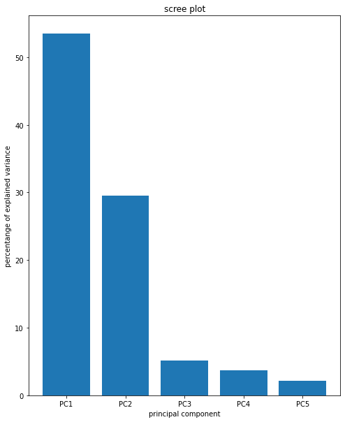

```python
# Show the amount of variation explained by the first 5 components
per_var = np.round(pca.explained_variance_ratio_ * 100, decimals=1)
labels = ['PC' + str(x) for x in range(1, len(per_var) + 1)]
plt.bar(x=range(1, len(per_var)+1), height=per_var, tick_label=labels)
plt.ylabel('percentange of explained variance')
plt.xlabel('principal component')
plt.title('scree plot')
plt.show()
```

Q7.3 How many components are needed to express 80% of the variation of the data?

Two components are needed to explain 80% of the variation of the data

Q7.4 What is your interpretation of the 1st component?  
Ans: From the first component certain cluster of fund value can be clearly described by the initial weeks of the calendar year having high(positive values) from PCA1 column in the above table.

Q 8.1 & 8.2 Common and difference in PCA and lasso  
Ans: PCA can be used as a dimensionality reduction technique if you drop Principal Components based on a heuristic, but it offers no feature selection, as the Principal Components are retained instead of the original features. However, tuning the number of Principal Components retained should work better than using heuristics, unless there are many low variance components and you are simply interested in filtering them.

LASSO (ℓ1 regularization) on the other hand can, intrinsically, perform feature selection as the coefficients of predictors are shrunk towards zero. It still requires hyperparameter tuning because there's a regularization coefficient that weights how severe is the regularization of the loss function.

```python
# Q 9 Run a regression of Y versus the PCA scores
# Reshaping the data into  proper date format
from datetime import datetime
data['Date'] = pd.to_datetime(data['Date'])
data['date'] = (data['Date'].dt.strftime('%Y-%m'))
data = data.drop('Date', axis = 1)
data.head()
```

|  | LUXXX | MSCI ARGENTINA | BLP ORIENTE MEDIO | MSCI AUSTRALIA | MSCI AUSTRIA | MSCI BELGIUM | MSCI BRAZIL | MSCI CANADA | MSCI CHINA | MSCI DENMARK | ... | MSCI PERU | MSCI RUSSIA | MSCI SINGAPORE | MSCI SOUTH AFRICA | MSCI SPAIN | MSCI SWEDEN | MSCI SWITZERLAND | MSCI UK | MSCI USA | date |
| --- | --- | --- | --- | --- | --- | --- | --- | --- | --- | --- | --- | --- | --- | --- | --- | --- | --- | --- | --- | --- | --- |
| 0 | 1390.716 | 2376.29 | 3525.9150 | 1068.79 | 106.70 | 105.38 | 1036.23 | 1663.27 | 59.47 | 8566.71 | ... | 811.96 | 404.73 | 1507.8101 | 1255.75 | 108.40 | 11136.65 | 1148.37 | 1818.40 | 1949.70 | 2016-01 |
| 1 | 1291.267 | 2260.85 | 3280.6683 | 1005.56 | 97.66 | 99.35 | 952.01 | 1586.18 | 54.63 | 8183.00 | ... | 751.09 | 388.05 | 1437.6600 | 1177.76 | 101.00 | 10389.93 | 1075.30 | 1722.00 | 1831.88 | 2016-01 |
| 2 | 1257.086 | 2217.50 | 3118.2981 | 985.38 | 93.54 | 97.32 | 904.64 | 1541.08 | 51.54 | 7755.73 | ... | 720.23 | 344.45 | 1372.9800 | 1133.72 | 97.34 | 10042.32 | 1056.01 | 1692.43 | 1789.56 | 2016-01 |
| 3 | 1254.167 | 2281.98 | 2935.0677 | 985.87 | 95.79 | 100.73 | 879.17 | 1582.10 | 51.15 | 8035.69 | ... | 745.96 | 367.44 | 1350.0500 | 1160.48 | 99.21 | 10469.07 | 1076.48 | 1719.61 | 1814.12 | 2016-01 |
| 4 | 1298.240 | 2462.19 | 3134.0840 | 1005.56 | 96.93 | 103.05 | 958.97 | 1638.84 | 52.13 | 8211.17 | ... | 825.18 | 400.93 | 1375.1000 | 1239.58 | 100.06 | 10432.42 | 1087.17 | 1774.40 | 1843.88 | 2016-01 |

5 rows × 36 columns

```python
data.drop('date', axis= 1, inplace=True)
data.head()
```

|  | LUXXX | MSCI ARGENTINA | BLP ORIENTE MEDIO | MSCI AUSTRALIA | MSCI AUSTRIA | MSCI BELGIUM | MSCI BRAZIL | MSCI CANADA | MSCI CHINA | MSCI DENMARK | ... | MSCI NORWAY | MSCI PERU | MSCI RUSSIA | MSCI SINGAPORE | MSCI SOUTH AFRICA | MSCI SPAIN | MSCI SWEDEN | MSCI SWITZERLAND | MSCI UK | MSCI USA |
| --- | --- | --- | --- | --- | --- | --- | --- | --- | --- | --- | --- | --- | --- | --- | --- | --- | --- | --- | --- | --- | --- |
| 0 | 1390.716 | 2376.29 | 3525.9150 | 1068.79 | 106.70 | 105.38 | 1036.23 | 1663.27 | 59.47 | 8566.71 | ... | 2373.17 | 811.96 | 404.73 | 1507.8101 | 1255.75 | 108.40 | 11136.65 | 1148.37 | 1818.40 | 1949.70 |
| 1 | 1291.267 | 2260.85 | 3280.6683 | 1005.56 | 97.66 | 99.35 | 952.01 | 1586.18 | 54.63 | 8183.00 | ... | 2209.38 | 751.09 | 388.05 | 1437.6600 | 1177.76 | 101.00 | 10389.93 | 1075.30 | 1722.00 | 1831.88 |
| 2 | 1257.086 | 2217.50 | 3118.2981 | 985.38 | 93.54 | 97.32 | 904.64 | 1541.08 | 51.54 | 7755.73 | ... | 2095.60 | 720.23 | 344.45 | 1372.9800 | 1133.72 | 97.34 | 10042.32 | 1056.01 | 1692.43 | 1789.56 |
| 3 | 1254.167 | 2281.98 | 2935.0677 | 985.87 | 95.79 | 100.73 | 879.17 | 1582.10 | 51.15 | 8035.69 | ... | 2173.55 | 745.96 | 367.44 | 1350.0500 | 1160.48 | 99.21 | 10469.07 | 1076.48 | 1719.61 | 1814.12 |
| 4 | 1298.240 | 2462.19 | 3134.0840 | 1005.56 | 96.93 | 103.05 | 958.97 | 1638.84 | 52.13 | 8211.17 | ... | 2214.88 | 825.18 | 400.93 | 1375.1000 | 1239.58 | 100.06 | 10432.42 | 1087.17 | 1774.40 | 1843.88 |

5 rows × 35 columns

```python
X = data.drop('LUXXX', axis = 1) ## controlling variable)
y = data.LUXXX ## target Variable
```

```python
#  we fitted  the Linear regression using Principal Component Analysis using 10 features extracted
from sklearn.preprocessing import StandardScaler
from sklearn.decomposition import PCA
from sklearn.linear_model import LinearRegression
from sklearn.pipeline import Pipeline

# Principal components regression (PCA)
steps = [
    ('scale', StandardScaler()),
    ('pca', PCA()),
    ('estimator', LinearRegression())
]
pipe = Pipeline(steps)
pca = pipe.set_params(pca__n_components=10)
pca.fit(X, y)
```

```
Pipeline(steps=[('scale', StandardScaler()), ('pca', PCA(n_components=10)),
                ('estimator', LinearRegression())])
```